# Florida Coral Symbiont Shifts

Ross Cunning

2026-11-23

# Goal

Test whether symbiont composition changed across sampling eras while accounting for uneven sampling depth among eras.

This cleaned analysis uses post-MED ITS2 sequence variants only. Type profiles, exploratory maps, old commented code, and temporary one-off exports were removed. The working composition scale is symbiont clade/genus: `A`, `B`, `C`, `D`, and `G`.

# Required input files

Copy these files from the previous project into the paths below.

```r
required_files
```

```
## # A tibble: 4 × 3
##   key                    path                                        description
##   <chr>                  <chr>                                       <chr>
## 1 metadata               metadata/decadalshifts_SST.xls              Sample met…
## 2 pawar_variants         data/raw/20240723T194127_Pawar_Run /post_m… SymPortal …
## 3 conn_variants          data/raw/20250717T180136_conntr1/post_med_… SymPortal …
## 4 experimental_shuffling data/raw/experimental_shuffling_coef.csv    Experiment…
```

```r
missing_files <- required_files |>
  filter(!file.exists(path))

if (nrow(missing_files) > 0) {
  knitr::kable(missing_files, caption = "Files still needed before the analysis can run.")
  knitr::knit_exit()
}
```

# Load and clean data

```r
metadata <- load_sample_metadata("metadata/decadalshifts_SST.xls")

variant_runs <- load_variant_runs(c(
  pawar = required_files$path[required_files$key == "pawar_variants"],
  conn = required_files$path[required_files$key == "conn_variants"]
))

sample_clades <- prepare_sample_clade_composition(
  metadata = metadata,
  variants = variant_runs,
  min_reads = 100
)

sample_retention <- audit_sample_retention(
  metadata = metadata,
  variants = variant_runs,
  min_reads = 100
)

readr::write_csv(sample_clades, "data/processed/sample_clade_composition.csv")
readr::write_csv(sample_retention$stage_counts, "outputs/tables/sample_retention_audit.csv")
readr::write_csv(sample_retention$dropped_samples, "outputs/tables/dropped_samples.csv")
```

## Audit sample retention

Review how many imported samples are retained after metadata matching, Florida filtering, era assignment, and read-depth filtering.

```r
sample_retention$stage_counts |>
  knitr::kable(caption = "Sample retention audit")
```

Sample retention audit

| run_id | retention_status | collection_region | collection_subregion | era | n |
| --- | --- | --- | --- | --- | --- |
| conn | dropped: non-Florida sample | BDA | NA | 2001-03 | 165 |
| conn | dropped: post-MED reads < threshold | BDA | NA | 2001-03 | 121 |
| conn | dropped: post-MED reads < threshold | FL | Dry Tortugas | 2024 | 20 |
| conn | dropped: post-MED reads < threshold | FL | Upper Keys | 2024 | 20 |
| conn | kept | FL | Dry Tortugas | 2019-21 | 100 |
| conn | kept | FL | Dry Tortugas | 2024 | 267 |
| conn | kept | FL | Marquesas | 2019-21 | 90 |
| conn | kept | FL | Upper Keys | 2024 | 354 |
| pawar | dropped: post-MED reads < threshold | FL | Upper Keys | 2001-03 | 20 |
| pawar | dropped: post-MED reads < threshold | FL | Upper Keys | 2019-21 | 14 |
| pawar | kept | FL | Upper Keys | 2001-03 | 146 |
| pawar | kept | FL | Upper Keys | 2019-21 | 242 |

```r
if (nrow(sample_retention$duplicate_sample_names) > 0) {
  sample_retention$duplicate_sample_names |>
    knitr::kable(caption = "Sample names present in more than one imported run")
}
```

## Summarize samples by era

Visualize the retained samples across collection subregions, host species, and sampling eras before any species-group filtering.

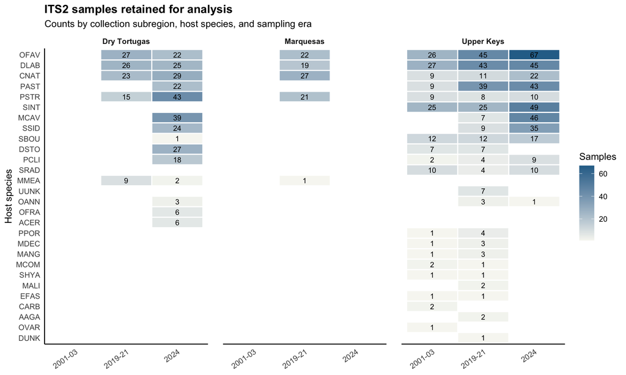

```r
sample_summary <- sample_clades |>
  count(collection_subregion, host_species_code, era, name = "n") |>
  arrange(collection_subregion, host_species_code, era)

plot_sample_count_heatmap <- function(summary_df, title, subtitle) {
  species_order <- summary_df |>
    group_by(host_species_code) |>
    summarize(total = sum(n), .groups = "drop") |>
    arrange(total) |>
    pull(host_species_code)

  summary_df |>
    mutate(
      era = factor(era, levels = eras),
      host_species_code = factor(host_species_code, levels = species_order)
    ) |>
    ggplot(aes(x = era, y = host_species_code, fill = n)) +
    geom_tile(color = "white", linewidth = 0.6) +
    geom_text(aes(label = n), size = 3) +
    facet_wrap(~ collection_subregion, nrow = 1) +
    scale_fill_gradient(low = "#f7f7f2", high = "#2a6f97", name = "Samples") +
    labs(
      x = NULL,
      y = "Host species",
      fill = "Samples",
      title = title,
      subtitle = subtitle
    ) +
    theme_classic() +
    theme(
      plot.title = element_text(face = "bold"),
      strip.background = element_blank(),
      strip.text = element_text(face = "bold"),
      panel.spacing.x = unit(1.2, "lines"),
      axis.text.x = element_text(angle = 35, hjust = 1),
      axis.ticks = element_blank(),
      panel.grid = element_blank()
    )
}

plot_sample_count_heatmap(
  sample_summary,
  title = "ITS2 samples retained for analysis",
  subtitle = "Counts by collection subregion, host species, and sampling era"
)
```

## Filter analysis groups

Keep only subregion-by-species groups with enough samples for era comparisons: at least `sample_filter_min_total` total samples and at least `sample_filter_min_eras` eras with `sample_filter_min_n` samples.

```r
sample_filter_min_n <- 2
sample_filter_min_eras <- 2
sample_filter_min_total <- 11

sample_group_filter <- sample_summary |>
  group_by(collection_subregion, host_species_code) |>
  summarize(
    total_n = sum(n),
    eras_at_min_n = sum(n >= sample_filter_min_n),
    retained = total_n >= sample_filter_min_total & eras_at_min_n >= sample_filter_min_eras,
    .groups = "drop"
  )

sample_filter_audit <- sample_group_filter |>
  count(collection_subregion, retained, name = "n_species_groups")

knitr::kable(
  sample_filter_audit,
  caption = paste(
    "Species groups retained with total n >=",
    sample_filter_min_total,
    "and at least",
    sample_filter_min_eras,
    "eras with n >=",
    sample_filter_min_n
  )
)
```

Species groups retained with total n >= 11 and at least 2 eras with n >= 2

| collection_subregion | retained | n_species_groups |
| --- | --- | --- |
| Dry Tortugas | FALSE | 9 |
| Dry Tortugas | TRUE | 5 |
| Marquesas | FALSE | 5 |
| Upper Keys | FALSE | 13 |
| Upper Keys | TRUE | 12 |

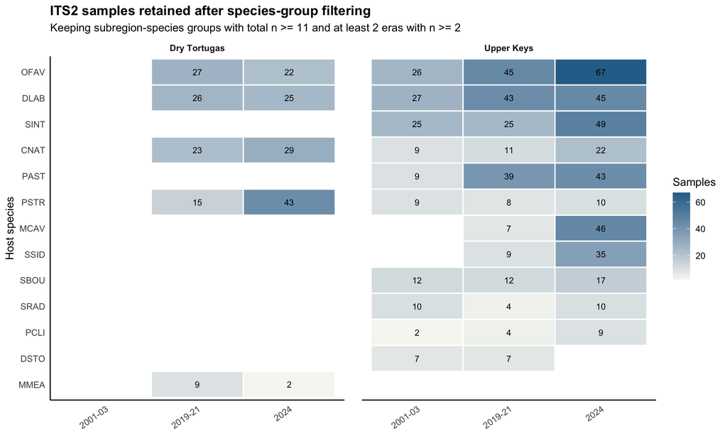

```r
retained_sample_groups <- sample_group_filter |>
  filter(retained) |>
  select(collection_subregion, host_species_code)

sample_summary_retained <- sample_summary |>
  semi_join(retained_sample_groups, by = c("collection_subregion", "host_species_code"))

plot_sample_count_heatmap(
  sample_summary_retained,
  title = "ITS2 samples retained after species-group filtering",
  subtitle = paste(
    "Keeping subregion-species groups with total n >=",
    sample_filter_min_total,
    "and at least",
    sample_filter_min_eras,
    "eras with n >=",
    sample_filter_min_n
  )
)
```

## Harmonize collection site names

Create a harmonized site-name variable before site-level diagnostics. Current manual rules only modify Upper Keys names; other subregions retain their raw site names.

```r
sample_clades_retained <- sample_clades |>
  semi_join(retained_sample_groups, by = c("collection_subregion", "host_species_code")) |>
  mutate(
    collection_site_harmonized = case_when(
      collection_subregion == "Upper Keys" &
        str_detect(str_to_lower(collection_site), "cheeca") ~ "Cheeca Rocks",
      collection_subregion == "Upper Keys" &
        str_detect(str_to_lower(collection_site), "outer reef") ~ "Outer Reef",
      collection_subregion == "Upper Keys" &
        str_to_lower(collection_site) %in% c("conch", "conch reef") ~ "Conch",
      collection_subregion == "Upper Keys" &
        collection_site %in% c("Hens and Chickens", "Tavernier Rocks") ~ "Tavernier Rocks",
      TRUE ~ collection_site
    )
  )
```

## Summarize retained sites

Break the filtered samples down by harmonized collection site, host species, and sampling era. Within each site, era slots are ordered left-to-right as `2001-03`, `2019-21`, and `2024`.

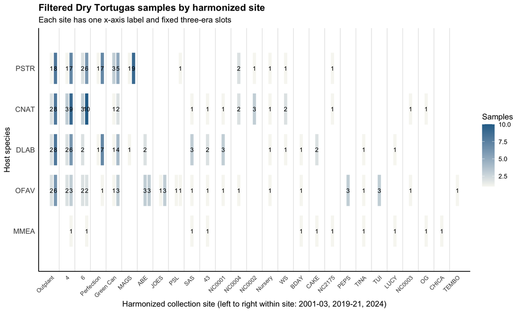

```r
site_species_summary <- sample_clades_retained |>
  filter(!is.na(collection_site_harmonized), !is.na(era)) |>
  count(
    collection_subregion, collection_site_harmonized,
    host_species_code, era,
    name = "n_samples"
  )

plot_site_species_heatmap <- function(summary_df, subregion) {
  subregion_df <- summary_df |>
    filter(collection_subregion == subregion)

  site_positions <- subregion_df |>
    group_by(collection_site_harmonized) |>
    summarize(
      site_n = sum(n_samples),
      n_2024 = sum(if_else(era == "2024", n_samples, 0L)),
      .groups = "drop"
    ) |>
    arrange(desc(n_2024), desc(site_n), collection_site_harmonized) |>
    mutate(site_index = row_number())

  species_positions <- subregion_df |>
    group_by(host_species_code) |>
    summarize(species_n = sum(n_samples), .groups = "drop") |>
    arrange(species_n) |>
    mutate(species_y = row_number())

  era_offsets <- tibble(
    era = factor(eras, levels = eras),
    era_offset = c(-0.26, 0, 0.26)
  )

  plot_df <- subregion_df |>
    left_join(site_positions, by = "collection_site_harmonized") |>
    left_join(species_positions, by = "host_species_code") |>
    left_join(era_offsets, by = "era") |>
    mutate(x = site_index + era_offset)

  site_breaks <- site_positions |>
    filter(site_index < max(site_index)) |>
    mutate(xintercept = site_index + 0.5)

  ggplot(plot_df, aes(x = x, y = species_y, fill = n_samples)) +
    geom_vline(
      data = site_breaks,
      aes(xintercept = xintercept),
      color = "grey84",
      linewidth = 0.25
    ) +
    geom_tile(width = 0.24, height = 0.78, color = "white", linewidth = 0.35) +
    geom_text(aes(label = n_samples), size = 3) +
    scale_x_continuous(
      breaks = site_positions$site_index,
      labels = site_positions$collection_site_harmonized,
      expand = expansion(add = 0.7)
    ) +
    scale_y_continuous(
      breaks = species_positions$species_y,
      labels = species_positions$host_species_code,
      expand = expansion(add = 0.6)
    ) +
    scale_fill_gradient(low = "#f7f7f2", high = "#2a6f97", name = "Samples") +
    labs(
      x = "Harmonized collection site (left to right within site: 2001-03, 2019-21, 2024)",
      y = "Host species",
      title = paste("Filtered", subregion, "samples by harmonized site"),
      subtitle = "Each site has one x-axis label and fixed three-era slots"
    ) +
    theme_classic() +
    theme(
      plot.title = element_text(face = "bold"),
      axis.text.x = element_text(angle = 45, hjust = 1, size = 8),
      axis.text.y = element_text(size = 10),
      axis.ticks = element_blank(),
      panel.grid = element_blank()
    )
}

plot_site_species_heatmap(site_species_summary, "Dry Tortugas")
```

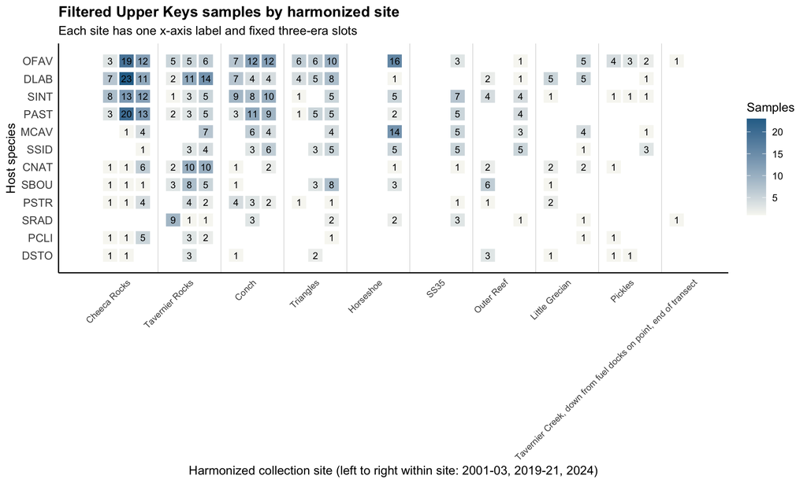

```r
plot_site_species_heatmap(site_species_summary, "Upper Keys")
```

## Map retained sampling locations

Each point represents a distinct recorded coordinate among samples retained after species-group filtering; overlapping samples share a point. The map extent is an estimate based on the reference image, which did not contain geographic coordinates. It assumes a north-up Web Mercator projection, so alignment with the original background may require adjustment. The transparent PNG has the same pixel dimensions and extent as the reference image and can be placed over an image with the same crop and projection.

```r
# Approximate reference-image bounds inferred from the visible sampling markers.
# Define the vertical extent from the image aspect ratio in projected space.
reference_width_px <- 6673
reference_height_px <- 3222
reference_lon_limits <- c(-83.57016, -79.56436)
reference_top_latitude <- 26.10897
mercator_radius <- 6378137
map_x_limits <- mercator_radius * reference_lon_limits * pi / 180
map_y_top <- mercator_radius * log(tan(pi / 4 + reference_top_latitude * pi / 360))
map_y_limits <- c(
  map_y_top - diff(map_x_limits) * reference_height_px / reference_width_px,
  map_y_top
)

map_samples <- sample_clades_retained |>
  mutate(
    valid_coordinates = is.finite(longitude) & is.finite(latitude) &
      between(longitude, -180, 180) & between(latitude, -85.0511, 85.0511),
    map_x = if_else(valid_coordinates, mercator_radius * longitude * pi / 180, NA_real_),
    map_y = if_else(valid_coordinates,
      mercator_radius * log(tan(pi / 4 + latitude * pi / 360)), NA_real_),
    in_map_extent = valid_coordinates & between(map_x, map_x_limits[1], map_x_limits[2]) &
      between(map_y, map_y_limits[1], map_y_limits[2])
  )

map_samples |>
  summarize(
    retained_samples = n(),
    missing_or_invalid_coordinates = sum(!valid_coordinates),
    outside_estimated_extent = sum(valid_coordinates & !in_map_extent),
    plotted_samples = sum(in_map_extent),
    distinct_plotted_coordinates = n_distinct(paste(longitude[in_map_extent], latitude[in_map_extent]))
  ) |>
  knitr::kable(caption = "Coverage of retained samples in the sampling location map")
```

Coverage of retained samples in the sampling location map

| retained_samples | missing_or_invalid_coordinates | outside_estimated_extent | plotted_samples | distinct_plotted_coordinates |
| --- | --- | --- | --- | --- |
| 924 | 0 | 0 | 924 | 43 |

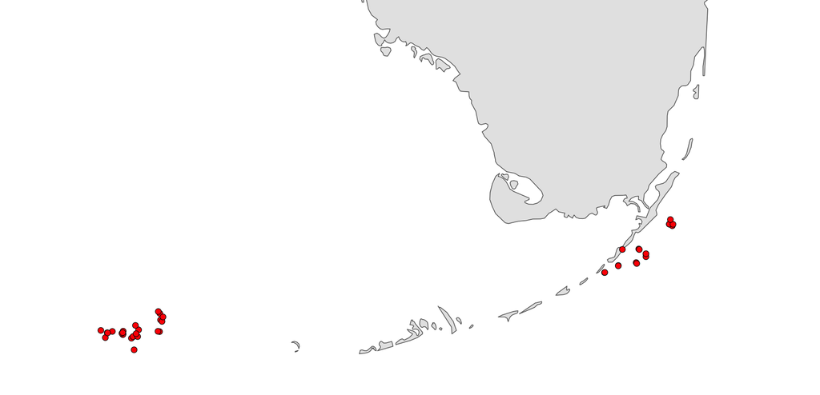

```r
map_locations <- map_samples |>
  filter(in_map_extent) |>
  distinct(longitude, latitude) |>
  sf::st_as_sf(coords = c("longitude", "latitude"), crs = 4326) |>
  sf::st_transform(3857)

florida_outline <- rnaturalearth::ne_states(
  country = "united states of america", returnclass = "sf"
) |>
  filter(name == "Florida") |>
  sf::st_transform(3857)

map_coordinates <- coord_sf(
  crs = sf::st_crs(3857), xlim = map_x_limits, ylim = map_y_limits,
  expand = FALSE, datum = NA
)
map_theme <- theme_void() + theme(
  plot.margin = margin(0, 0, 0, 0),
  panel.background = element_rect(fill = "transparent", color = NA),
  plot.background = element_rect(fill = "transparent", color = NA)
)
map_points <- geom_sf(data = map_locations, shape = 21, fill = "red",
                      color = "black", size = 2.2, stroke = 0.35)

sampling_map <- ggplot() +
  geom_sf(data = florida_outline, fill = "grey90", color = "grey40", linewidth = 0.3) +
  map_points + map_coordinates + map_theme
sampling_map
```

```r
sampling_points_overlay <- ggplot() + map_points + map_coordinates + map_theme
ggsave(
  "outputs/figures/retained_sampling_locations_overlay.png",
  sampling_points_overlay,
  width = reference_width_px, height = reference_height_px, units = "px",
  dpi = 500, bg = "transparent"
)
```

# Sampling depth diagnostics

Summarize depth distributions by harmonized collection site, host species, and era to check whether cross-era comparisons are being driven by site-level depth differences.

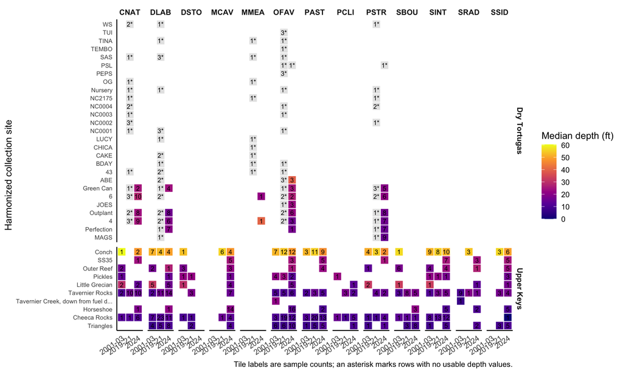

```r
depth_summary <- sample_clades_retained |>
  group_by(
    collection_subregion, collection_site_harmonized,
    host_species_code, era
  ) |>
  summarize(
    n = n(),
    n_depth = sum(!is.na(depth_ft)),
    median_depth_ft = median(depth_ft, na.rm = TRUE),
    q25_depth_ft = quantile(depth_ft, 0.25, na.rm = TRUE),
    q75_depth_ft = quantile(depth_ft, 0.75, na.rm = TRUE),
    .groups = "drop"
  ) |>
  mutate(
    across(
      c(median_depth_ft, q25_depth_ft, q75_depth_ft),
      ~ if_else(is.nan(.x), NA_real_, .x)
    )
  )

readr::write_csv(depth_summary, "outputs/tables/depth_summary_by_harmonized_site_era.csv")

site_depth_order <- depth_summary |>
  group_by(collection_subregion, collection_site_harmonized) |>
  summarize(
    site_n = sum(n),
    median_site_depth_ft = median(median_depth_ft, na.rm = TRUE),
    .groups = "drop"
  ) |>
  arrange(collection_subregion, median_site_depth_ft, collection_site_harmonized) |>
  pull(collection_site_harmonized) |>
  unique()

depth_summary_plot <- depth_summary |>
  mutate(
    collection_site_harmonized = factor(collection_site_harmonized, levels = site_depth_order),
    site_plot_label = str_trunc(as.character(collection_site_harmonized), width = 36),
    site_plot_label = factor(site_plot_label, levels = str_trunc(site_depth_order, width = 36)),
    era = factor(era, levels = eras),
    depth_label = if_else(n_depth > 0, as.character(n), paste0(n, "*"))
  )

ggplot(depth_summary_plot, aes(x = era, y = site_plot_label)) +
  geom_tile(aes(fill = median_depth_ft), color = "white", linewidth = 0.35) +
  geom_text(aes(label = depth_label), size = 2.6) +
  facet_grid(
    collection_subregion ~ host_species_code,
    scales = "free_y",
    space = "free_y"
  ) +
  scale_fill_viridis_c(
    option = "C",
    na.value = "grey90",
    name = "Median depth (ft)"
  ) +
  labs(
    x = NULL,
    y = "Harmonized collection site",
    caption = "Tile labels are sample counts; an asterisk marks rows with no usable depth values."
  ) +
  theme_classic() +
  theme(
    strip.background = element_blank(),
    strip.text = element_text(face = "bold"),
    axis.text.x = element_text(angle = 35, hjust = 1),
    axis.text.y = element_text(size = 7),
    axis.ticks = element_blank()
  )
```

```r
ggsave("outputs/figures/depth_by_harmonized_site_era.png", width = 12, height = 8, dpi = 300)
```

# Symbiont composition

For each subregion-by-species group, samples are weighted so each era better matches the pooled distribution of harmonized collection sites and, where available, pooled depth bins. This preserves the observed samples while reducing bias from eras being sampled at different sites or depths.

Dry Tortugas samples are site-standardized but not depth-standardized because one era lacks depth information. Other subregion-by-species groups without usable depth information are also retained and standardized only by the available design variables.

Groups with fewer than `min_n` samples in an era are retained with `NA` composition for that era rather than silently dropped.

```r
min_n <- sample_filter_min_n

composition_std <- standardized_era_composition(
  sample_clades_retained,
  min_n = min_n,
  n_bins = 6,
  no_depth_standardization_subregions = "Dry Tortugas"
)

standardization_targets <- standardization_target_distribution(
  sample_clades_retained,
  composition = composition_std,
  n_bins = 6,
  no_depth_standardization_subregions = "Dry Tortugas"
)

standardization_target_margins <- bind_rows(
  standardization_targets |>
    filter(!is.na(collection_site_harmonized)) |>
    summarize(
      n_target = sum(n_target),
      target_total_n = first(target_total_n),
      target_proportion = sum(target_proportion),
      target_percent = 100 * target_proportion,
      .by = c(collection_subregion, host_species_code, standardization_method, collection_site_harmonized)
    ) |>
    transmute(
      collection_subregion, host_species_code, standardization_method,
      target_variable = "site",
      target_level = collection_site_harmonized,
      n_target, target_total_n, target_proportion, target_percent
    ),
  standardization_targets |>
    filter(!is.na(depth_bin)) |>
    summarize(
      n_target = sum(n_target),
      target_total_n = first(target_total_n),
      target_proportion = sum(target_proportion),
      target_percent = 100 * target_proportion,
      .by = c(collection_subregion, host_species_code, standardization_method, depth_bin)
    ) |>
    transmute(
      collection_subregion, host_species_code, standardization_method,
      target_variable = "depth_bin",
      target_level = depth_bin,
      n_target, target_total_n, target_proportion, target_percent
    )
) |>
  arrange(collection_subregion, host_species_code, target_variable, desc(target_proportion), target_level)

era_distances <- compare_eras(composition_std)

across_region_composition <- combine_regions_by_species(
  composition_std,
  regions = c("Upper Keys", "Dry Tortugas"),
  region_weighting = "equal"
)

across_region_distances <- compare_eras_by_species(across_region_composition)

readr::write_csv(composition_std, "data/processed/site_depth_standardized_composition.csv")
readr::write_csv(standardization_targets, "outputs/tables/composition_standardization_targets.csv")
readr::write_csv(
  standardization_target_margins,
  "outputs/tables/composition_standardization_target_margins.csv"
)
readr::write_csv(era_distances, "outputs/tables/era_composition_distances.csv")
readr::write_csv(
  across_region_composition,
  "data/processed/across_region_species_composition.csv"
)
readr::write_csv(
  across_region_distances,
  "outputs/tables/across_region_species_era_distances.csv"
)
```

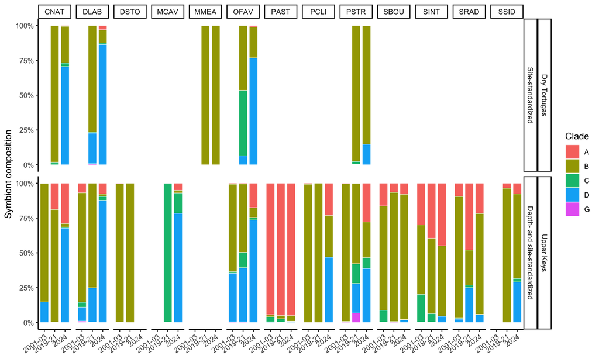

```r
composition_long <- composition_std |>
  pivot_longer(all_of(clades), names_to = "clade", values_to = "proportion") |>
  filter(!is.na(proportion))

ggplot(composition_long, aes(x = era, y = proportion, fill = clade)) +
  geom_col(width = 0.8, color = "white", linewidth = 0.2) +
  facet_grid(collection_subregion + standardization_method ~ host_species_code) +
  scale_y_continuous(labels = scales::percent_format(accuracy = 1)) +
  labs(x = NULL, y = "Symbiont composition", fill = "Clade") +
  theme_classic() +
  theme(axis.text.x = element_text(angle = 35, hjust = 1))
```

```r
ggsave("outputs/figures/site_depth_standardized_composition.png", width = 13, height = 7, dpi = 300)
```

# Statistical test

The primary test is a PERMANOVA on clade composition within each subregion-by-species group. Era is evaluated after available design terms, so groups with site and depth structure are tested as:

`composition ~ depth_bin + site + era`

Groups without usable depth data are kept and tested as:

`composition ~ site + era`

These tests are paired with the composition summaries above so the biological effect sizes are interpretable.

```r
permanova_results <- permanova_by_group(
  sample_clades_retained,
  min_n = min_n,
  permutations = 999,
  no_depth_adjustment_subregions = "Dry Tortugas"
)

readr::write_csv(permanova_results, "outputs/tables/permanova_by_subregion_species.csv")

format_p <- function(p) {
  case_when(
    is.na(p) ~ "",
    p < 0.001 ~ "&lt;0.001***",
    p < 0.01 ~ sprintf("%.3f**", p),
    p < 0.05 ~ sprintf("%.3f*", p),
    TRUE ~ sprintf("%.3f", p)
  )
}

format_sig_p <- function(p) {
  formatted <- format_p(p)
  if_else(!is.na(p) & p < 0.05, paste0("<strong>", formatted, "</strong>"), formatted)
}

permanova_results |>
  arrange(host_species_code, collection_subregion) |>
  select(-site_adjusted, -depth_adjusted) |>
  mutate(
    p_depth_bin = format_sig_p(p_depth_bin),
    p_site = format_sig_p(p_site),
    p_era = format_sig_p(p_era)
  ) |>
  knitr::kable(escape = FALSE)
```

| collection_subregion | host_species_code | n | eras_tested | test_formula | r2_depth_bin | p_depth_bin | r2_site | p_site | r2_era | p_era |
| --- | --- | --- | --- | --- | --- | --- | --- | --- | --- | --- |
| Dry Tortugas | CNAT | 52 | 2 | composition ~ site_factor + era | NA |  | 0.2721534 | **0.034*** | 0.2948251 | **0.001**** |
| Upper Keys | CNAT | 42 | 3 | composition ~ depth_bin + site_factor + era | 0.2112662 | **0.001**** | 0.2389574 | **0.001**** | 0.3385049 | **0.001**** |
| Dry Tortugas | DLAB | 51 | 2 | composition ~ site_factor + era | NA |  | 0.5225390 | **0.001**** | 0.1704831 | **0.001**** |
| Upper Keys | DLAB | 115 | 3 | composition ~ depth_bin + site_factor + era | 0.1144605 | **0.001**** | 0.1279936 | **0.001**** | 0.3929725 | **0.001**** |
| Upper Keys | DSTO | 14 | 2 | composition ~ depth_bin + site_factor + era | 0.8676935 | **0.025*** | 0.0955806 | 0.175 | 0.0047353 | 0.419 |
| Upper Keys | MCAV | 53 | 2 | composition ~ depth_bin + site_factor + era | 0.5293724 | **0.001**** | 0.1251429 | **0.033*** | 0.0699493 | **0.001**** |
| Dry Tortugas | MMEA | 11 | 2 | composition ~ site_factor + era | NA |  | NA |  | NA |  |
| Dry Tortugas | OFAV | 49 | 2 | composition ~ site_factor + era | NA |  | 0.3741937 | 0.058 | 0.2235502 | **0.001**** |
| Upper Keys | OFAV | 138 | 3 | composition ~ depth_bin + site_factor + era | 0.2206462 | **0.001**** | 0.1354530 | **0.001**** | 0.1061284 | **0.001**** |
| Upper Keys | PAST | 91 | 3 | composition ~ depth_bin + site_factor + era | 0.1471317 | **0.009**** | 0.0138463 | 0.949 | 0.0193451 | 0.401 |
| Upper Keys | PCLI | 15 | 3 | composition ~ depth_bin + site_factor + era | 0.3221303 | 0.132 | 0.3461952 | 0.099 | 0.1987887 | 0.091 |
| Dry Tortugas | PSTR | 58 | 2 | composition ~ site_factor + era | NA |  | 0.0866526 | 0.860 | 0.0243160 | 0.272 |
| Upper Keys | PSTR | 27 | 3 | composition ~ depth_bin + site_factor + era | 0.2203442 | 0.147 | 0.1285191 | 0.511 | 0.2695167 | **0.004**** |
| Upper Keys | SBOU | 41 | 3 | composition ~ depth_bin + site_factor + era | 0.2143270 | **0.025*** | 0.3274024 | **0.028*** | 0.0256075 | 0.435 |
| Upper Keys | SINT | 99 | 3 | composition ~ depth_bin + site_factor + era | 0.5360359 | **0.001**** | 0.1841081 | **0.001**** | 0.0209335 | **0.017*** |
| Upper Keys | SRAD | 24 | 3 | composition ~ depth_bin + site_factor + era | 0.2690608 | 0.081 | 0.3661984 | 0.092 | 0.0096904 | 0.545 |
| Upper Keys | SSID | 44 | 2 | composition ~ depth_bin + site_factor + era | 0.2154400 | **0.032*** | 0.1905318 | 0.249 | 0.0568360 | 0.071 |

## Site/depth-standardized composition shifts

Summarize pairwise era shifts using Hellinger distances calculated from the site/depth-standardized composition estimates above. Points include subregion-specific shifts and a species-level field summary that averages available subregions equally when more than one subregion is available.

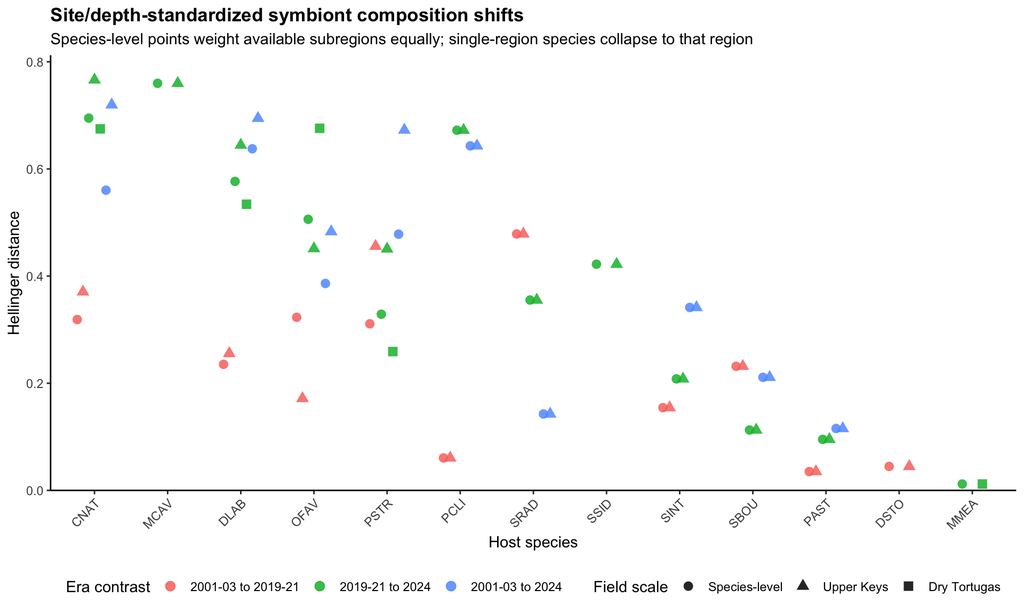

```r
standardized_shift_plot_data <- bind_rows(
  era_distances |>
    filter(!is.na(Hellinger)) |>
    transmute(
      field_scale = collection_subregion,
      host_species_code,
      era1, era2,
      Hellinger
    ),
  across_region_distances |>
    filter(!is.na(Hellinger)) |>
    transmute(
      field_scale = "Species-level",
      host_species_code,
      era1, era2,
      Hellinger
    )
) |>
  mutate(
    contrast = factor(
      paste(era1, "to", era2),
      levels = c("2001-03 to 2019-21", "2019-21 to 2024", "2001-03 to 2024")
    ),
    field_scale = factor(
      field_scale,
      levels = c("Species-level", "Upper Keys", "Dry Tortugas")
    )
  )

standardized_shift_species_order <- standardized_shift_plot_data |>
  summarize(max_hellinger = max(Hellinger), .by = host_species_code) |>
  arrange(desc(max_hellinger)) |>
  pull(host_species_code)

standardized_shift_plot_data <- standardized_shift_plot_data |>
  mutate(
    host_species_code = factor(host_species_code, levels = standardized_shift_species_order)
  )

standardized_shift_plot <- ggplot(
  standardized_shift_plot_data,
  aes(x = host_species_code, y = Hellinger, color = contrast, shape = field_scale)
) +
  geom_point(
    position = position_dodge(width = 0.55),
    size = 2.8,
    alpha = 0.85
  ) +
  scale_y_continuous(limits = c(0, NA), expand = expansion(mult = c(0, 0.06))) +
  labs(
    x = "Host species",
    y = "Hellinger distance",
    color = "Era contrast",
    shape = "Field scale",
    title = "Site/depth-standardized symbiont composition shifts",
    subtitle = "Species-level points weight available subregions equally; single-region species collapse to that region"
  ) +
  theme_classic() +
  theme(
    plot.title = element_text(face = "bold"),
    axis.text.x = element_text(angle = 45, hjust = 1),
    legend.position = "bottom"
  )

standardized_shift_plot
```

```r
ggsave("outputs/figures/site_depth_standardized_hellinger_shifts_by_species.png", standardized_shift_plot, width = 11, height = 6.5, dpi = 300)
```

# Field-observed composition take-homes

Before comparing field shifts to experimental shuffling, the table and figure below summarize the field observations on their own. These species-level values use the same standardized composition estimates as above: Upper Keys estimates are standardized across site and depth, Dry Tortugas estimates are standardized across site, and species with both subregions available are averaged across subregions equally.

```r
field_observed_shift_summary <- across_region_composition |>
  filter(era %in% c("2019-21", "2024")) |>
  mutate(era_key = if_else(era == "2019-21", "era_2019_21", "era_2024")) |>
  select(
    host_species_code,
    era_key,
    n_total,
    n_regions,
    regions_included,
    durusdinium = D
  ) |>
  pivot_wider(
    names_from = era_key,
    values_from = c(durusdinium, n_total, n_regions, regions_included),
    names_sep = "__"
  ) |>
  left_join(
    across_region_distances |>
      filter(era1 == "2019-21", era2 == "2024") |>
      select(host_species_code, hellinger_2019_21_to_2024 = Hellinger),
    by = "host_species_code"
  ) |>
  filter(
    !is.na(durusdinium__era_2019_21),
    !is.na(durusdinium__era_2024)
  ) |>
  mutate(
    durusdinium_change = durusdinium__era_2024 - durusdinium__era_2019_21
  )

field_observed_species_labels <- function(flags) {
  species <- field_observed_shift_summary$host_species_code[flags]
  if (length(species) == 0) {
    "None"
  } else {
    paste(sort(species), collapse = ", ")
  }
}

field_observed_metric_table <- tibble(
  `Field-observed summary` = c(
    "2024 Durusdinium >= 50%",
    "2024 Durusdinium >= 75%",
    "2024 Durusdinium >= 90%",
    "Increase >= 25 percentage points from 2019-21 to 2024",
    "Increase >= 50 percentage points from 2019-21 to 2024",
    "Shift from <25% to >=50% Durusdinium",
    "Whole-community Hellinger distance >= 0.5"
  ),
  n_species = c(
    sum(field_observed_shift_summary$durusdinium__era_2024 >= 0.50),
    sum(field_observed_shift_summary$durusdinium__era_2024 >= 0.75),
    sum(field_observed_shift_summary$durusdinium__era_2024 >= 0.90),
    sum(field_observed_shift_summary$durusdinium_change >= 0.25),
    sum(field_observed_shift_summary$durusdinium_change >= 0.50),
    sum(
      field_observed_shift_summary$durusdinium__era_2019_21 < 0.25 &
        field_observed_shift_summary$durusdinium__era_2024 >= 0.50
    ),
    sum(field_observed_shift_summary$hellinger_2019_21_to_2024 >= 0.50)
  ),
  species = c(
    field_observed_species_labels(field_observed_shift_summary$durusdinium__era_2024 >= 0.50),
    field_observed_species_labels(field_observed_shift_summary$durusdinium__era_2024 >= 0.75),
    field_observed_species_labels(field_observed_shift_summary$durusdinium__era_2024 >= 0.90),
    field_observed_species_labels(field_observed_shift_summary$durusdinium_change >= 0.25),
    field_observed_species_labels(field_observed_shift_summary$durusdinium_change >= 0.50),
    field_observed_species_labels(
      field_observed_shift_summary$durusdinium__era_2019_21 < 0.25 &
        field_observed_shift_summary$durusdinium__era_2024 >= 0.50
    ),
    field_observed_species_labels(field_observed_shift_summary$hellinger_2019_21_to_2024 >= 0.50)
  )
)

field_observed_metric_table |>
  knitr::kable(
    caption = "High-level field-observed Durusdinium shift metrics from species-level 2019-21 to 2024 comparisons"
  )
```

High-level field-observed Durusdinium shift metrics from species-level 2019-21 to 2024 comparisons

| Field-observed summary | n_species | species |
| --- | --- | --- |
| 2024 Durusdinium >= 50% | 4 | CNAT, DLAB, MCAV, OFAV |
| 2024 Durusdinium >= 75% | 3 | DLAB, MCAV, OFAV |
| 2024 Durusdinium >= 90% | 0 | None |
| Increase >= 25 percentage points from 2019-21 to 2024 | 6 | CNAT, DLAB, MCAV, OFAV, PCLI, SSID |
| Increase >= 50 percentage points from 2019-21 to 2024 | 4 | CNAT, DLAB, MCAV, OFAV |
| Shift from <25% to >=50% Durusdinium | 4 | CNAT, DLAB, MCAV, OFAV |
| Whole-community Hellinger distance >= 0.5 | 5 | CNAT, DLAB, MCAV, OFAV, PCLI |

```r
field_observed_species_table <- field_observed_shift_summary |>
  arrange(desc(durusdinium__era_2024)) |>
  transmute(
    `Host species` = host_species_code,
    `Durusdinium 2019-21` = scales::percent(durusdinium__era_2019_21, accuracy = 0.1),
    `Durusdinium 2024` = scales::percent(durusdinium__era_2024, accuracy = 0.1),
    `Change` = paste0(
      if_else(durusdinium_change >= 0, "+", ""),
      round(100 * durusdinium_change, 1),
      " pp"
    ),
    `Hellinger distance` = round(hellinger_2019_21_to_2024, 3),
    `n 2019-21` = n_total__era_2019_21,
    `n 2024` = n_total__era_2024,
    `Subregions included` = regions_included__era_2024
  )

field_observed_species_table |>
  knitr::kable(
    caption = "Species-level field-observed Durusdinium dominance and whole-community shift magnitude"
  )
```

Species-level field-observed Durusdinium dominance and whole-community shift magnitude

| Host species | Durusdinium 2019-21 | Durusdinium 2024 | Change | Hellinger distance | n 2019-21 | n 2024 | Subregions included |
| --- | --- | --- | --- | --- | --- | --- | --- |
| DLAB | 23.3% | 87.0% | +63.7 pp | 0.577 | 69 | 70 | Dry Tortugas; Upper Keys |
| MCAV | 0.2% | 78.4% | +78.2 pp | 0.760 | 7 | 46 | Upper Keys |
| OFAV | 22.6% | 75.2% | +52.5 pp | 0.506 | 72 | 89 | Dry Tortugas; Upper Keys |
| CNAT | 0.1% | 69.1% | +69 pp | 0.695 | 34 | 51 | Dry Tortugas; Upper Keys |
| PCLI | 0.0% | 46.8% | +46.8 pp | 0.672 | 4 | 9 | Upper Keys |
| SSID | 0.0% | 29.1% | +29.1 pp | 0.422 | 9 | 35 | Upper Keys |
| PSTR | 10.8% | 26.7% | +16 pp | 0.329 | 23 | 53 | Dry Tortugas; Upper Keys |
| SRAD | 25.0% | 5.6% | -19.3 pp | 0.355 | 4 | 10 | Upper Keys |
| SINT | 0.2% | 4.4% | +4.2 pp | 0.208 | 25 | 49 | Upper Keys |
| SBOU | 0.0% | 1.8% | +1.8 pp | 0.113 | 12 | 17 | Upper Keys |
| PAST | 0.1% | 0.7% | +0.6 pp | 0.095 | 39 | 43 | Upper Keys |
| MMEA | 0.0% | 0.0% | +0 pp | 0.012 | 9 | 2 | Dry Tortugas |

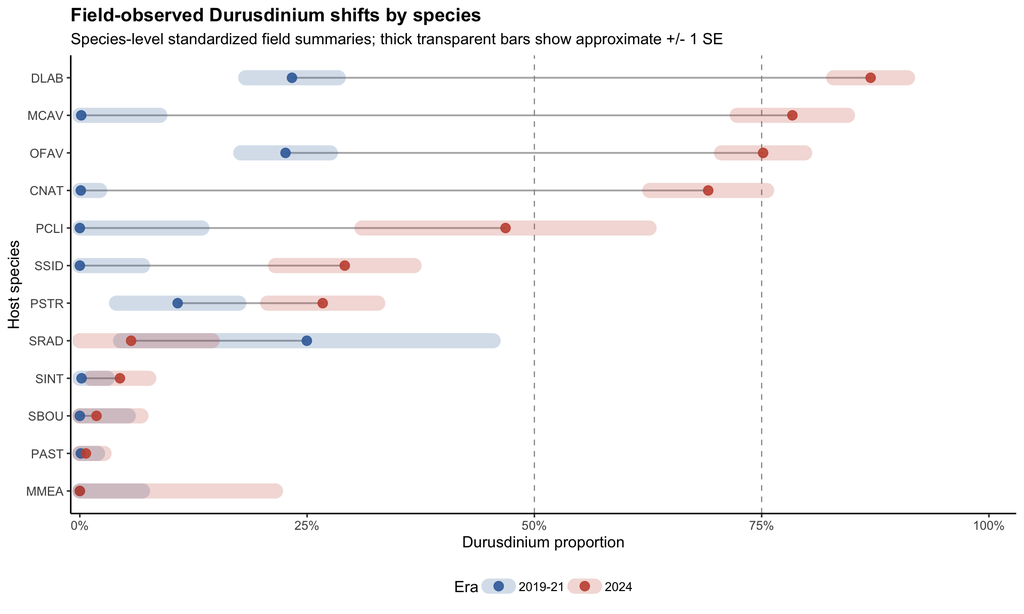

```r
make_field_observed_genus_plot <- function(genus_col, genus_name) {
  plot_data <- across_region_composition |>
    filter(era %in% c("2019-21", "2024")) |>
    transmute(
      host_species_code,
      era,
      n_total,
      genus_proportion = .data[[genus_col]]
    ) |>
    group_by(host_species_code) |>
    filter(all(c("2019-21", "2024") %in% era)) |>
    ungroup()

  species_order <- plot_data |>
    filter(era == "2024") |>
    arrange(genus_proportion) |>
    pull(host_species_code)

  plot_data <- plot_data |>
    mutate(
      host_species_code = factor(host_species_code, levels = species_order),
      era = factor(era, levels = c("2019-21", "2024")),
      genus_count = genus_proportion * n_total,
      genus_adjusted = (genus_count + 0.5) / (n_total + 1),
      genus_se = sqrt(genus_adjusted * (1 - genus_adjusted) / (n_total + 1)),
      genus_lower = pmax(0, genus_proportion - genus_se),
      genus_upper = pmin(1, genus_proportion + genus_se)
    )

  ggplot(plot_data, aes(x = genus_proportion, y = host_species_code)) +
    geom_line(
      aes(group = host_species_code),
      color = "grey70",
      linewidth = 0.6
    ) +
    geom_vline(
      xintercept = c(0.50, 0.75),
      linetype = "dashed",
      color = "grey60",
      linewidth = 0.4
    ) +
    geom_segment(
      aes(
        x = genus_lower,
        xend = genus_upper,
        yend = host_species_code,
        color = era
      ),
      linewidth = 5,
      alpha = 0.22,
      lineend = "round"
    ) +
    geom_point(aes(color = era), size = 2.8, alpha = 0.9) +
    scale_x_continuous(
      labels = scales::percent_format(accuracy = 1),
      limits = c(0, 1),
      expand = expansion(mult = c(0.01, 0.03))
    ) +
    scale_color_manual(values = c("2019-21" = "#3B6EA8", "2024" = "#C7533F")) +
    labs(
      x = paste(genus_name, "proportion"),
      y = "Host species",
      color = "Era",
      title = paste("Field-observed", genus_name, "shifts by species"),
      subtitle = "Species-level standardized field summaries; thick transparent bars show approximate +/- 1 SE"
    ) +
    theme_classic() +
    theme(
      plot.title = element_text(face = "bold"),
      legend.position = "bottom"
    )
}

field_observed_durusdinium_plot <- make_field_observed_genus_plot("D", "Durusdinium")
field_observed_symbiodinium_plot <- make_field_observed_genus_plot("A", "Symbiodinium")
field_observed_breviolum_plot <- make_field_observed_genus_plot("B", "Breviolum")
field_observed_cladocopium_plot <- make_field_observed_genus_plot("C", "Cladocopium")

field_observed_durusdinium_plot
```

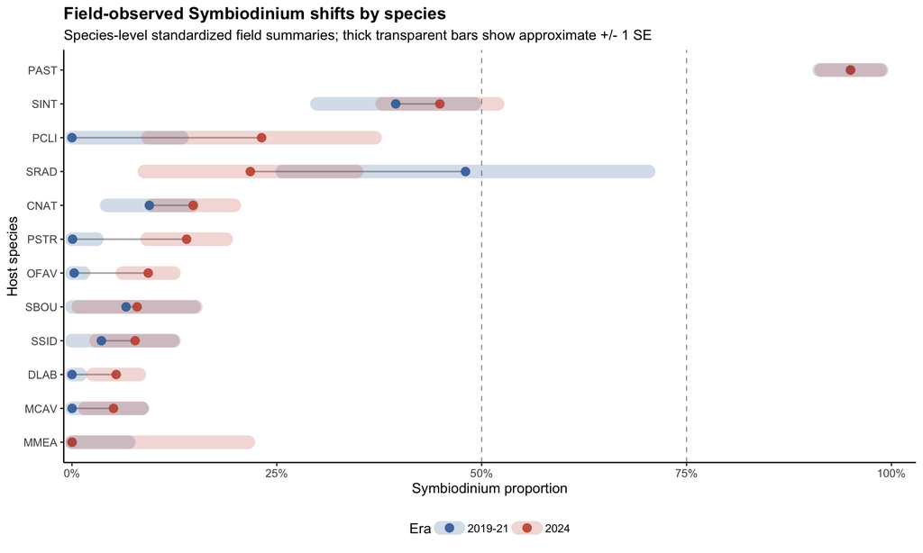

```r
field_observed_symbiodinium_plot
```

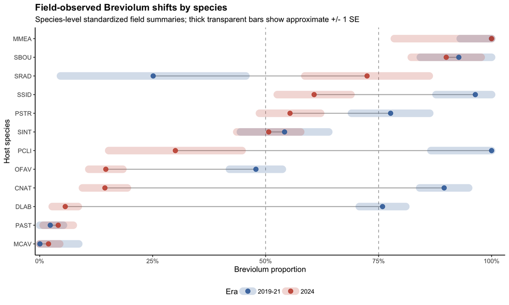

```r
field_observed_breviolum_plot
```

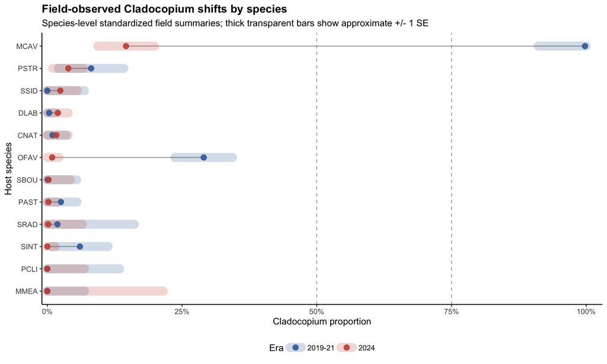

```r
field_observed_cladocopium_plot
```

```r
ggsave("outputs/figures/field_observed_durusdinium_shifts_by_species.png", field_observed_durusdinium_plot, width = 9, height = 6.5, dpi = 300)
ggsave("outputs/figures/field_observed_symbiodinium_shifts_by_species.png", field_observed_symbiodinium_plot, width = 9, height = 6.5, dpi = 300)
ggsave("outputs/figures/field_observed_breviolum_shifts_by_species.png", field_observed_breviolum_plot, width = 9, height = 6.5, dpi = 300)
ggsave("outputs/figures/field_observed_cladocopium_shifts_by_species.png", field_observed_cladocopium_plot, width = 9, height = 6.5, dpi = 300)
```

## Sample-level dominance and mixing

The genus-proportion plots above summarize the standardized average ITS2 profile for each species and era. The companion plots below classify individual samples first, then summarize the standardized fraction of samples in each category. These plots help distinguish a shift caused by many colonies becoming dominated by a genus from a shift caused by more mixed communities within colonies.

```r
genus_labels <- c(
  A = "Symbiodinium",
  B = "Breviolum",
  C = "Cladocopium",
  D = "Durusdinium",
  G = "Gerakladium"
)

sample_level_metric_cols <- c(
  paste0("dominant_", clades),
  "durusdinium_ge_50",
  "durusdinium_ge_75",
  "durusdinium_ge_90"
)

field_observed_sample_metrics <- sample_clades_retained |>
  mutate(
    dominant_genus = recode(dominant_clade, !!!genus_labels),
    across(all_of(clades), ~ replace_na(.x, 0))
  ) |>
  mutate(
    dominant_A = as.numeric(dominant_clade == "A"),
    dominant_B = as.numeric(dominant_clade == "B"),
    dominant_C = as.numeric(dominant_clade == "C"),
    dominant_D = as.numeric(dominant_clade == "D"),
    dominant_G = as.numeric(dominant_clade == "G"),
    durusdinium_ge_50 = as.numeric(D >= 0.50),
    durusdinium_ge_75 = as.numeric(D >= 0.75),
    durusdinium_ge_90 = as.numeric(D >= 0.90)
  )

weighted_sample_metric_summary <- function(data, metric_cols,
                                           group_cols = c("collection_subregion", "host_species_code"),
                                           min_n = 2, n_bins = 6,
                                           site_col = "collection_site_harmonized",
                                           no_depth_standardization_subregions = "Dry Tortugas") {
  data |>
    group_by(across(all_of(group_cols))) |>
    group_modify(\(.x, .y) {
      df <- .x
      subregion <- if ("collection_subregion" %in% names(.y)) .y$collection_subregion else NA_character_
      skip_depth_standardization <- !is.na(subregion) && subregion %in% no_depth_standardization_subregions
      has_complete_depth <- all(!is.na(df$depth_ft))
      depth_bins <- if (has_complete_depth) make_depth_bins(df$depth_ft, n_bins = n_bins) else factor(rep(NA_character_, nrow(df)))
      use_depth_standardization <- !skip_depth_standardization && has_complete_depth && !all(is.na(depth_bins))
      use_site_standardization <- site_col %in% names(df) && n_distinct(df[[site_col]], na.rm = TRUE) > 1

      if (use_depth_standardization) {
        df <- mutate(df, depth_bin = depth_bins)
      }

      strata_cols <- c(
        if (use_depth_standardization) "depth_bin",
        if (use_site_standardization) site_col
      )

      map_dfr(eras, \(era_i) {
        era_df <- filter(df, era == era_i)
        n_samples <- nrow(era_df)

        if (n_samples < min_n) {
          metric_values <- set_names(rep(NA_real_, length(metric_cols)), metric_cols)
        } else {
          weights <- if (length(strata_cols) > 0) {
            stratification_weights(era_df, df, strata_cols)
          } else {
            rep(1, n_samples)
          }

          if (sum(weights, na.rm = TRUE) == 0) {
            weights <- rep(1, n_samples)
          }

          weights <- weights / sum(weights, na.rm = TRUE)
          metric_values <- map_dbl(metric_cols, \(metric_col) {
            sum(era_df[[metric_col]] * weights, na.rm = TRUE)
          }) |>
            set_names(metric_cols)
        }

        tibble(era = era_i, n = n_samples, !!!as.list(metric_values))
      })
    }) |>
    ungroup() |>
    mutate(era = factor(era, levels = eras))
}

sample_metric_by_region <- weighted_sample_metric_summary(
  field_observed_sample_metrics,
  sample_level_metric_cols,
  min_n = min_n,
  n_bins = 6,
  no_depth_standardization_subregions = "Dry Tortugas"
)

sample_metric_across_region <- sample_metric_by_region |>
  filter(if_any(all_of(sample_level_metric_cols), ~ !is.na(.x))) |>
  summarize(
    n_total = sum(n),
    n_regions = n_distinct(collection_subregion),
    regions_included = paste(sort(unique(collection_subregion)), collapse = "; "),
    across(all_of(sample_level_metric_cols), ~ mean(.x, na.rm = TRUE)),
    .by = c(host_species_code, era)
  )

sample_level_plot_species <- sample_metric_across_region |>
  filter(era %in% c("2019-21", "2024"), !is.na(dominant_D)) |>
  summarize(n_eras = n_distinct(era), .by = host_species_code) |>
  filter(n_eras == 2) |>
  pull(host_species_code)

durusdinium_sample_prevalence_table <- sample_metric_across_region |>
  filter(
    host_species_code %in% sample_level_plot_species,
    era %in% c("2019-21", "2024")
  ) |>
  mutate(era_key = if_else(era == "2019-21", "era_2019_21", "era_2024")) |>
  select(
    host_species_code, era_key, n_total,
    dominant_D,
    durusdinium_ge_50,
    durusdinium_ge_75,
    durusdinium_ge_90
  ) |>
  pivot_wider(
    names_from = era_key,
    values_from = c(n_total, dominant_D, durusdinium_ge_50, durusdinium_ge_75, durusdinium_ge_90),
    names_sep = "__"
  ) |>
  filter(!is.na(dominant_D__era_2019_21), !is.na(dominant_D__era_2024)) |>
  transmute(
    `Host species` = host_species_code,
    `Durusdinium-dominant 2019-21` = scales::percent(dominant_D__era_2019_21, accuracy = 1),
    `Durusdinium-dominant 2024` = scales::percent(dominant_D__era_2024, accuracy = 1),
    `>=75% Durusdinium 2024` = scales::percent(durusdinium_ge_75__era_2024, accuracy = 1),
    `>=90% Durusdinium 2024` = scales::percent(durusdinium_ge_90__era_2024, accuracy = 1),
    `n 2019-21` = n_total__era_2019_21,
    `n 2024` = n_total__era_2024
  )

durusdinium_sample_prevalence_table |>
  knitr::kable(
    caption = "Standardized sample-level Durusdinium prevalence. Values are fractions of samples/colonies, not mean sequence composition."
  )
```

Standardized sample-level Durusdinium prevalence. Values are fractions of samples/colonies, not mean sequence composition.

| Host species | Durusdinium-dominant 2019-21 | Durusdinium-dominant 2024 | >=75% Durusdinium 2024 | >=90% Durusdinium 2024 | n 2019-21 | n 2024 |
| --- | --- | --- | --- | --- | --- | --- |
| CNAT | 0% | 79% | 50% | 40% | 34 | 51 |
| DLAB | 25% | 90% | 85% | 79% | 69 | 70 |
| MMEA | 0% | 0% | 0% | 0% | 9 | 2 |
| OFAV | 25% | 76% | 71% | 67% | 72 | 89 |
| PSTR | 12% | 28% | 22% | 13% | 23 | 53 |
| MCAV | 0% | 79% | 75% | 69% | 7 | 46 |
| PAST | 0% | 0% | 0% | 0% | 39 | 43 |
| PCLI | 0% | 50% | 40% | 40% | 4 | 9 |
| SBOU | 0% | 0% | 0% | 0% | 12 | 17 |
| SINT | 0% | 2% | 1% | 1% | 25 | 49 |
| SRAD | 25% | 9% | 0% | 0% | 4 | 10 |
| SSID | 0% | 29% | 22% | 14% | 9 | 35 |

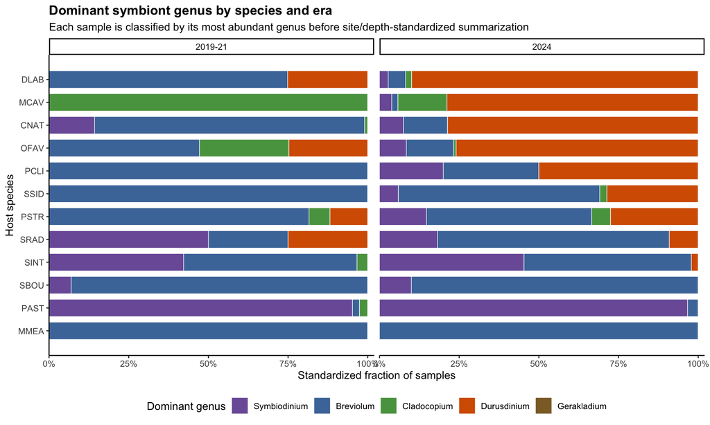

```r
dominant_genus_plot_data <- sample_metric_across_region |>
  filter(
    host_species_code %in% sample_level_plot_species,
    era %in% c("2019-21", "2024")
  ) |>
  select(host_species_code, era, starts_with("dominant_")) |>
  pivot_longer(
    cols = starts_with("dominant_"),
    names_to = "dominant_clade",
    values_to = "prevalence"
  ) |>
  mutate(
    genus = recode(str_remove(dominant_clade, "^dominant_"), !!!genus_labels)
  )

dominant_genus_species_order <- dominant_genus_plot_data |>
  filter(era == "2024", genus == "Durusdinium") |>
  arrange(prevalence) |>
  pull(host_species_code) |>
  unique()

dominant_genus_species_order <- c(
  dominant_genus_species_order,
  setdiff(sort(unique(dominant_genus_plot_data$host_species_code)), dominant_genus_species_order)
)

dominant_genus_plot_stacked <- dominant_genus_plot_data |>
  mutate(
    host_species_code = factor(host_species_code, levels = dominant_genus_species_order),
    era = factor(era, levels = c("2019-21", "2024")),
    genus = factor(genus, levels = unname(genus_labels))
  ) |>
  arrange(era, host_species_code, genus) |>
  group_by(era, host_species_code) |>
  mutate(
    xmin = cumsum(lag(prevalence, default = 0)),
    xmax = pmin(1, xmin + prevalence),
    y = as.numeric(host_species_code)
  ) |>
  ungroup()

dominant_genus_plot <- ggplot(dominant_genus_plot_stacked) +
  geom_rect(
    aes(
      xmin = xmin,
      xmax = xmax,
      ymin = y - 0.38,
      ymax = y + 0.38,
      fill = genus
    ),
    color = "white",
    linewidth = 0.25
  ) +
  facet_wrap(~ era, nrow = 1) +
  scale_x_continuous(
    labels = scales::percent_format(accuracy = 1),
    expand = expansion(mult = c(0, 0.02))
  ) +
  scale_y_continuous(
    breaks = seq_along(dominant_genus_species_order),
    labels = dominant_genus_species_order,
    expand = expansion(add = 0.7)
  ) +
  scale_fill_manual(
    values = c(
      Symbiodinium = "#7B5EA7",
      Breviolum = "#4C78A8",
      Cladocopium = "#59A14F",
      Durusdinium = "#D55E00",
      Gerakladium = "#8C6D31"
    ),
    drop = FALSE
  ) +
  coord_cartesian(xlim = c(0, 1)) +
  labs(
    x = "Standardized fraction of samples",
    y = "Host species",
    fill = "Dominant genus",
    title = "Dominant symbiont genus by species and era",
    subtitle = "Each sample is classified by its most abundant genus before site/depth-standardized summarization"
  ) +
  theme_classic() +
  theme(
    plot.title = element_text(face = "bold"),
    legend.position = "bottom"
  )

dominant_genus_plot
```

```r
ggsave("outputs/figures/field_observed_dominant_genus_by_species_era.png", dominant_genus_plot, width = 11, height = 6.5, dpi = 300)
```

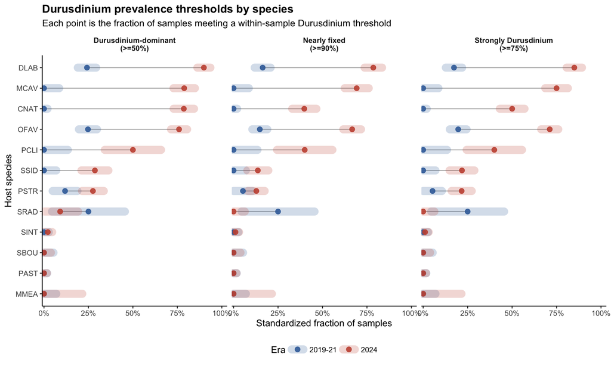

```r
durusdinium_threshold_plot_data <- sample_metric_across_region |>
  filter(
    host_species_code %in% sample_level_plot_species,
    era %in% c("2019-21", "2024")
  ) |>
  select(
    host_species_code, era, n_total,
    `Durusdinium-dominant\n(>=50%)` = durusdinium_ge_50,
    `Strongly Durusdinium\n(>=75%)` = durusdinium_ge_75,
    `Nearly fixed\n(>=90%)` = durusdinium_ge_90
  ) |>
  pivot_longer(
    cols = contains("Durusdinium") | contains("fixed"),
    names_to = "threshold",
    values_to = "prevalence"
  ) |>
  mutate(
    prevalence_count = prevalence * n_total,
    prevalence_adjusted = (prevalence_count + 0.5) / (n_total + 1),
    prevalence_se = sqrt(prevalence_adjusted * (1 - prevalence_adjusted) / (n_total + 1)),
    prevalence_lower = pmax(0, prevalence - prevalence_se),
    prevalence_upper = pmin(1, prevalence + prevalence_se)
  )

durusdinium_threshold_species_order <- durusdinium_threshold_plot_data |>
  filter(era == "2024", threshold == "Durusdinium-dominant\n(>=50%)") |>
  arrange(prevalence) |>
  pull(host_species_code) |>
  unique()

durusdinium_threshold_species_order <- c(
  durusdinium_threshold_species_order,
  setdiff(sort(unique(durusdinium_threshold_plot_data$host_species_code)), durusdinium_threshold_species_order)
)

durusdinium_threshold_plot <- durusdinium_threshold_plot_data |>
  mutate(
    host_species_code = factor(host_species_code, levels = durusdinium_threshold_species_order),
    era = factor(era, levels = c("2019-21", "2024"))
  ) |>
  ggplot(aes(x = prevalence, y = host_species_code)) +
  geom_line(aes(group = host_species_code), color = "grey70", linewidth = 0.5) +
  geom_segment(
    aes(
      x = prevalence_lower,
      xend = prevalence_upper,
      yend = host_species_code,
      color = era
    ),
    linewidth = 4.5,
    alpha = 0.22,
    lineend = "round"
  ) +
  geom_point(aes(color = era), size = 2.5, alpha = 0.9) +
  facet_wrap(~ threshold, nrow = 1) +
  scale_x_continuous(
    labels = scales::percent_format(accuracy = 1),
    limits = c(0, 1),
    expand = expansion(mult = c(0.01, 0.03))
  ) +
  scale_color_manual(values = c("2019-21" = "#3B6EA8", "2024" = "#C7533F")) +
  labs(
    x = "Standardized fraction of samples",
    y = "Host species",
    color = "Era",
    title = "Durusdinium prevalence thresholds by species",
    subtitle = "Each point is the fraction of samples meeting a within-sample Durusdinium threshold"
  ) +
  theme_classic() +
  theme(
    plot.title = element_text(face = "bold"),
    strip.background = element_blank(),
    strip.text = element_text(face = "bold"),
    legend.position = "bottom"
  )

durusdinium_threshold_plot
```

```r
ggsave("outputs/figures/field_observed_durusdinium_sample_thresholds_by_species.png", durusdinium_threshold_plot, width = 13, height = 6.5, dpi = 300)
```

# Field shifts versus experimental shuffling

The primary comparison asks whether species with stronger experimental shuffling responses also show larger field-measured shifts in symbiont composition. Because the experimental data are species-level rather than subregion-specific, the primary field response is the species-level site/depth-standardized Hellinger distance from `2019-21` to `2024`. Species with both Upper Keys and Dry Tortugas estimates are averaged across subregions; species with one available subregion use that subregion’s standardized field estimate.

The first table is a contrast-level screen: each row correlates the species-level field shift for one era contrast with the experimental shuffling coefficient. The `2019-21 to 2024` contrast is the direct comparison to the field samples collected closest to the experiment.

```r
experimental_shuffling <- load_experimental_shuffling(
  required_files$path[required_files$key == "experimental_shuffling"]
)

experimental_comparison <- compare_its2_to_experimental(
  composition = composition_std,
  distances = era_distances,
  experimental = experimental_shuffling
)

across_region_experimental <- compare_across_region_to_experimental(
  composition = across_region_composition,
  distances = across_region_distances,
  experimental = experimental_shuffling
)

readr::write_csv(
  across_region_experimental$distance,
  "outputs/tables/across_region_its2_distances_vs_experimental_shuffling.csv"
)
readr::write_csv(
  across_region_experimental$distance_correlations,
  "outputs/tables/across_region_correlations_its2_distances_vs_experimental_shuffling.csv"
)
readr::write_csv(
  across_region_experimental$composition,
  "outputs/tables/across_region_its2_2024_clade_d_vs_experimental_prop_d.csv"
)
readr::write_csv(
  across_region_experimental$composition_correlations,
  "outputs/tables/across_region_correlations_its2_2024_clade_d_vs_experimental_prop_d.csv"
)

across_region_experimental$distance_correlations |>
  arrange(contrast) |>
  knitr::kable(
    digits = 3,
    caption = paste(
      "Pearson correlations between species-level field Hellinger distance",
      "and experimental shuffling coefficient. Each row uses one era contrast;",
      "the 2019-21 to 2024 contrast is the primary comparison."
    )
  )
```

Pearson correlations between species-level field Hellinger distance and experimental shuffling coefficient. Each row uses one era contrast; the 2019-21 to 2024 contrast is the primary comparison.

| contrast | n_species | cor_hellinger_shuff_coef | p_hellinger_shuff_coef | cor_jsd_shuff_coef | p_jsd_shuff_coef |
| --- | --- | --- | --- | --- | --- |
| 2001-03 to 2019-21 | 7 | 0.145 | 0.756 | 0.145 | 0.756 |
| 2001-03 to 2024 | 7 | 0.615 | 0.142 | 0.621 | 0.137 |
| 2019-21 to 2024 | 10 | 0.743 | 0.014 | 0.762 | 0.010 |

```r
estimate_hellinger_response_se <- function(composition, distance_data, n_boot = 1000, seed = 20240630) {
  set.seed(seed)

  map_dfr(seq_len(nrow(distance_data)), \(i) {
    row <- distance_data[i, ]
    p1 <- composition |>
      filter(host_species_code == row$species_code, era == row$era1)
    p2 <- composition |>
      filter(host_species_code == row$species_code, era == row$era2)

    if (
      nrow(p1) != 1 || nrow(p2) != 1 ||
        anyNA(select(p1, all_of(clades))) || anyNA(select(p2, all_of(clades))) ||
        is.na(row$n1) || is.na(row$n2) || row$n1 <= 0 || row$n2 <= 0
    ) {
      return(tibble(species_code = row$species_code, contrast = row$contrast, Hellinger_se = NA_real_))
    }

    p1_vector <- as.numeric(select(p1, all_of(clades)))
    p2_vector <- as.numeric(select(p2, all_of(clades)))
    p1_draws <- t(rmultinom(n_boot, size = row$n1, prob = p1_vector)) / row$n1
    p2_draws <- t(rmultinom(n_boot, size = row$n2, prob = p2_vector)) / row$n2

    tibble(
      species_code = row$species_code,
      contrast = row$contrast,
      Hellinger_se = sd(map2_dbl(
        seq_len(n_boot),
        seq_len(n_boot),
        \(j, k) hellinger_distance(p1_draws[j, ], p2_draws[k, ])
      ))
    )
  })
}

experimental_field_shift_plot_data <- across_region_experimental$distance |>
  filter(
    contrast == "2019-21 to 2024",
    !is.na(mean_shuff_coef),
    !is.na(Hellinger)
  ) |>
  left_join(
    estimate_hellinger_response_se(across_region_composition, across_region_experimental$distance),
    by = c("species_code", "contrast")
  ) |>
  mutate(
    harmonic_field_n = 2 / (1 / n1 + 1 / n2),
    response_weight = 1 / Hellinger_se^2
  )

fit_lm_unweighted <- lm(Hellinger ~ mean_shuff_coef, data = experimental_field_shift_plot_data)
fit_lm_weighted <- lm(
  Hellinger ~ mean_shuff_coef,
  data = experimental_field_shift_plot_data,
  weights = response_weight
)
fit_rlm <- MASS::rlm(Hellinger ~ mean_shuff_coef, data = experimental_field_shift_plot_data)

summarize_lm_shift_model <- function(fit, method, fit_scale = "Raw Hellinger") {
  fit_summary <- summary(fit)
  tibble(
    method = method,
    fit_scale = fit_scale,
    n_species = length(fitted(fit)),
    intercept = coef(fit)[["(Intercept)"]],
    slope = coef(fit)[["mean_shuff_coef"]],
    slope_se = fit_summary$coefficients["mean_shuff_coef", "Std. Error"],
    slope_p = fit_summary$coefficients["mean_shuff_coef", "Pr(>|t|)"],
    r_squared = fit_summary$r.squared
  )
}

summarize_rlm_shift_model <- function(fit, method, fit_scale = "Raw Hellinger") {
  fit_summary <- summary(fit)
  slope <- fit_summary$coefficients["mean_shuff_coef", "Value"]
  slope_se <- fit_summary$coefficients["mean_shuff_coef", "Std. Error"]
  slope_t <- slope / slope_se
  n_species <- length(fitted(fit))
  observed <- model.response(model.frame(fit))

  tibble(
    method = method,
    fit_scale = fit_scale,
    n_species = n_species,
    intercept = coef(fit)[["(Intercept)"]],
    slope = slope,
    slope_se = slope_se,
    slope_p = 2 * pt(abs(slope_t), df = n_species - 2, lower.tail = FALSE),
    r_squared = 1 - sum(resid(fit)^2) / sum((observed - mean(observed))^2)
  )
}

experimental_shift_model_comparison <- bind_rows(
  summarize_lm_shift_model(fit_lm_unweighted, "Unweighted LM"),
  summarize_lm_shift_model(fit_lm_weighted, "Weighted LM (response SE)"),
  summarize_rlm_shift_model(fit_rlm, "Robust regression")
) |>
  mutate(slope_p_formatted = format_sig_p(slope_p))

experimental_shift_model_comparison |>
  select(method, fit_scale, n_species, intercept, slope, slope_se, slope_p = slope_p_formatted, r_squared) |>
  knitr::kable(
    digits = 3,
    escape = FALSE,
    caption = "Model comparison for the primary 2019-21 to 2024 field shift versus experimental shuffling coefficient. R-squared is ordinary R-squared for linear models and deviance pseudo-R-squared for fractional-logit models."
  )
```

Model comparison for the primary 2019-21 to 2024 field shift versus experimental shuffling coefficient. R-squared is ordinary R-squared for linear models and deviance pseudo-R-squared for fractional-logit models.

| method | fit_scale | n_species | intercept | slope | slope_se | slope_p | r_squared |
| --- | --- | --- | --- | --- | --- | --- | --- |
| Unweighted LM | Raw Hellinger | 10 | 0.087 | 0.841 | 0.268 | **0.014*** | 0.552 |
| Weighted LM (response SE) | Raw Hellinger | 10 | 0.007 | 1.053 | 0.169 | **<0.001***** | 0.828 |
| Robust regression | Raw Hellinger | 10 | 0.050 | 0.891 | 0.272 | **0.011*** | 0.543 |

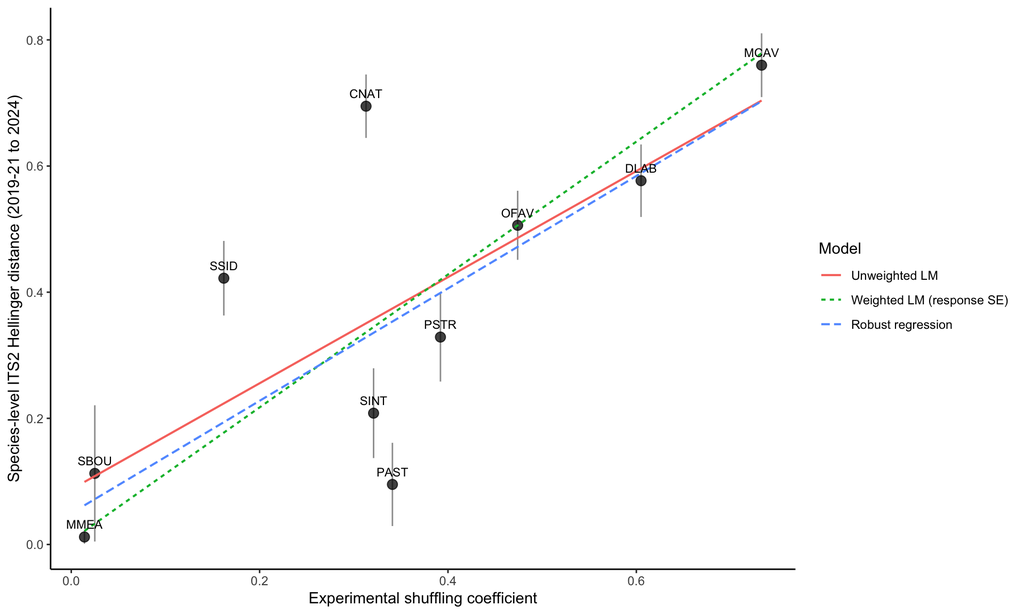

```r
experimental_shift_prediction_grid <- tibble(
  mean_shuff_coef = seq(
    min(experimental_field_shift_plot_data$mean_shuff_coef),
    max(experimental_field_shift_plot_data$mean_shuff_coef),
    length.out = 100
  )
)

experimental_shift_model_lines <- bind_rows(
  experimental_shift_prediction_grid |>
    mutate(
      method = "Unweighted LM",
      Hellinger = predict(fit_lm_unweighted, newdata = experimental_shift_prediction_grid)
    ),
  experimental_shift_prediction_grid |>
    mutate(
      method = "Weighted LM (response SE)",
      Hellinger = predict(fit_lm_weighted, newdata = experimental_shift_prediction_grid)
    ),
  experimental_shift_prediction_grid |>
    mutate(
      method = "Robust regression",
      Hellinger = predict(fit_rlm, newdata = experimental_shift_prediction_grid)
    )
  ) |>
  mutate(method = factor(method, levels = experimental_shift_model_comparison$method))

experimental_field_shift_plot <- ggplot(
  experimental_field_shift_plot_data,
  aes(x = mean_shuff_coef, y = Hellinger)
) +
  geom_errorbar(
    aes(ymin = pmax(0, Hellinger - Hellinger_se), ymax = pmin(1, Hellinger + Hellinger_se)),
    width = 0,
    alpha = 0.45
  ) +
  geom_point(size = 3, alpha = 0.75) +
  geom_line(
    data = experimental_shift_model_lines,
    aes(y = Hellinger, color = method, linetype = method),
    linewidth = 0.7
  ) +
  geom_text(
    aes(label = species_code),
    nudge_y = 0.02,
    check_overlap = TRUE,
    size = 3
  ) +
  labs(
    x = "Experimental shuffling coefficient",
    y = "Species-level ITS2 Hellinger distance (2019-21 to 2024)",
    color = "Model",
    linetype = "Model"
  ) +
  theme_classic()

experimental_field_shift_plot
```

```r
ggsave("outputs/figures/across_region_its2_distance_vs_experimental_shuffling.png", experimental_field_shift_plot, width = 8, height = 5, dpi = 300)
```

## Secondary Durusdinium endpoint comparison

The shuffling-coefficient analysis above focuses on whether experimental response strength predicts the magnitude of field ITS2 shifts. As a separate endpoint check, the table and plot below compare the final Durusdinium proportions measured in the experiment with the species-level 2024 field Durusdinium proportions.

```r
across_region_experimental$composition_correlations |>
  knitr::kable(
    digits = 3,
    caption = "Pearson correlation between species-level 2024 ITS2 Durusdinium proportion and experimental Durusdinium proportion"
  )
```

Pearson correlation between species-level 2024 ITS2 Durusdinium proportion and experimental Durusdinium proportion

| n_species | cor_its2_d_experimental_d | p_its2_d_experimental_d |
| --- | --- | --- |
| 10 | 0.695 | 0.026 |

```r
experimental_clade_d_plot <- across_region_experimental$composition |>
  filter(!is.na(mean_prop_d), !is.na(its2_prop_d_2024)) |>
  mutate(
    field_n = n_its2_2024,
    its2_prop_d_2024_count = its2_prop_d_2024 * n_its2_2024,
    its2_prop_d_2024_adjusted = (its2_prop_d_2024_count + 0.5) / (n_its2_2024 + 1),
    its2_prop_d_2024_se = sqrt(
      its2_prop_d_2024_adjusted * (1 - its2_prop_d_2024_adjusted) / (n_its2_2024 + 1)
    ),
    response_weight = 1 / its2_prop_d_2024_se^2
  )

fit_clade_d_lm_unweighted <- lm(its2_prop_d_2024 ~ mean_prop_d, data = experimental_clade_d_plot)
fit_clade_d_lm_weighted <- lm(
  its2_prop_d_2024 ~ mean_prop_d,
  data = experimental_clade_d_plot,
  weights = response_weight
)
fit_clade_d_rlm <- MASS::rlm(its2_prop_d_2024 ~ mean_prop_d, data = experimental_clade_d_plot)

summarize_clade_d_lm <- function(fit, method) {
  fit_summary <- summary(fit)
  tibble(
    method = method,
    n_species = length(fitted(fit)),
    intercept = coef(fit)[["(Intercept)"]],
    slope = coef(fit)[["mean_prop_d"]],
    slope_se = fit_summary$coefficients["mean_prop_d", "Std. Error"],
    slope_p = fit_summary$coefficients["mean_prop_d", "Pr(>|t|)"],
    r_squared = fit_summary$r.squared
  )
}

summarize_clade_d_rlm <- function(fit, method) {
  fit_summary <- summary(fit)
  slope <- fit_summary$coefficients["mean_prop_d", "Value"]
  slope_se <- fit_summary$coefficients["mean_prop_d", "Std. Error"]
  slope_t <- slope / slope_se
  n_species <- length(fitted(fit))
  observed <- model.response(model.frame(fit))

  tibble(
    method = method,
    n_species = n_species,
    intercept = coef(fit)[["(Intercept)"]],
    slope = slope,
    slope_se = slope_se,
    slope_p = 2 * pt(abs(slope_t), df = n_species - 2, lower.tail = FALSE),
    r_squared = 1 - sum(resid(fit)^2) / sum((observed - mean(observed))^2)
  )
}

experimental_clade_d_model_comparison <- bind_rows(
  summarize_clade_d_lm(fit_clade_d_lm_unweighted, "Unweighted LM"),
  summarize_clade_d_lm(fit_clade_d_lm_weighted, "Weighted LM (response SE)"),
  summarize_clade_d_rlm(fit_clade_d_rlm, "Robust regression")
) |>
  mutate(slope_p_formatted = format_sig_p(slope_p))

experimental_clade_d_model_comparison |>
  select(method, n_species, intercept, slope, slope_se, slope_p = slope_p_formatted, r_squared) |>
  knitr::kable(
    digits = 3,
    escape = FALSE,
    caption = "Model comparison for species-level 2024 ITS2 Durusdinium proportion versus experimental Durusdinium proportion"
  )
```

Model comparison for species-level 2024 ITS2 Durusdinium proportion versus experimental Durusdinium proportion

| method | n_species | intercept | slope | slope_se | slope_p | r_squared |
| --- | --- | --- | --- | --- | --- | --- |
| Unweighted LM | 10 | 0.069 | 0.709 | 0.259 | **0.026*** | 0.483 |
| Weighted LM (response SE) | 10 | -0.117 | 1.059 | 0.228 | **0.002**** | 0.730 |
| Robust regression | 10 | 0.021 | 0.852 | 0.247 | **0.009**** | 0.462 |

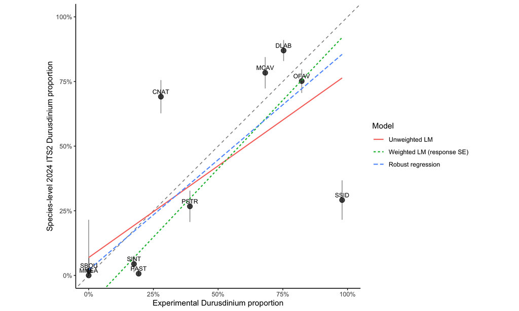

```r
experimental_clade_d_prediction_grid <- tibble(
  mean_prop_d = seq(
    min(experimental_clade_d_plot$mean_prop_d),
    max(experimental_clade_d_plot$mean_prop_d),
    length.out = 100
  )
)

experimental_clade_d_model_lines <- bind_rows(
  experimental_clade_d_prediction_grid |>
    mutate(
      method = "Unweighted LM",
      its2_prop_d_2024 = predict(fit_clade_d_lm_unweighted, newdata = experimental_clade_d_prediction_grid)
    ),
  experimental_clade_d_prediction_grid |>
    mutate(
      method = "Weighted LM (response SE)",
      its2_prop_d_2024 = predict(fit_clade_d_lm_weighted, newdata = experimental_clade_d_prediction_grid)
    ),
  experimental_clade_d_prediction_grid |>
    mutate(
      method = "Robust regression",
      its2_prop_d_2024 = predict(fit_clade_d_rlm, newdata = experimental_clade_d_prediction_grid)
    )
) |>
  mutate(method = factor(method, levels = experimental_clade_d_model_comparison$method))

experimental_clade_d_plot_out <- ggplot(experimental_clade_d_plot, aes(x = mean_prop_d, y = its2_prop_d_2024)) +
  geom_abline(slope = 1, intercept = 0, linetype = 2, color = "grey55") +
  geom_errorbar(
    aes(ymin = pmax(0, its2_prop_d_2024 - its2_prop_d_2024_se), ymax = pmin(1, its2_prop_d_2024 + its2_prop_d_2024_se)),
    width = 0,
    alpha = 0.45
  ) +
  geom_point(size = 3, alpha = 0.75) +
  geom_line(
    data = experimental_clade_d_model_lines,
    aes(y = its2_prop_d_2024, color = method, linetype = method),
    linewidth = 0.7
  ) +
  geom_text(
    aes(label = species_code),
    nudge_y = 0.02,
    check_overlap = TRUE,
    size = 3
  ) +
  coord_equal(xlim = c(0, 1), ylim = c(0, 1)) +
  scale_x_continuous(labels = scales::percent_format()) +
  scale_y_continuous(labels = scales::percent_format()) +
  labs(
    x = "Experimental Durusdinium proportion",
    y = "Species-level 2024 ITS2 Durusdinium proportion",
    color = "Model",
    linetype = "Model"
  ) +
  theme_classic()

experimental_clade_d_plot_out
```

```r
ggsave("outputs/figures/across_region_its2_2024_clade_d_vs_experimental_prop_d.png", experimental_clade_d_plot_out, width = 8, height = 5, dpi = 300)
```

## Integrated experimental comparison

```r
fit_shift_fractional_logit_weighted <- glm(
  Hellinger ~ mean_shuff_coef,
  data = experimental_field_shift_plot_data,
  weights = response_weight,
  family = quasibinomial(link = "logit")
)

fit_clade_d_fractional_logit_weighted <- glm(
  its2_prop_d_2024 ~ mean_prop_d,
  data = experimental_clade_d_plot,
  weights = response_weight,
  family = quasibinomial(link = "logit")
)

summarize_weighted_fractional_logit <- function(fit, method, slope_name) {
  fit_summary <- summary(fit)
  p_column <- grep("^Pr", colnames(fit_summary$coefficients), value = TRUE)

  tibble(
    method = method,
    model_family = "Quasibinomial GLM, logit link",
    n_species = length(fitted(fit)),
    intercept = coef(fit)[["(Intercept)"]],
    slope = coef(fit)[[slope_name]],
    slope_se = fit_summary$coefficients[slope_name, "Std. Error"],
    slope_p = fit_summary$coefficients[slope_name, p_column],
    r_squared = 1 - fit$deviance / fit$null.deviance
  ) |>
    mutate(slope_p_formatted = format_sig_p(slope_p))
}

integrated_experimental_model_comparison <- bind_rows(
  summarize_weighted_fractional_logit(
    fit_shift_fractional_logit_weighted,
    "Weighted fractional logit (response SE)",
    "mean_shuff_coef"
  ) |>
    mutate(
      endpoint = "Composition-shift magnitude",
      predictor = "Experimental shuffling coefficient",
      response = "2019-21 to 2024 Hellinger distance",
      model_role = "Displayed bounded model"
    ),
  experimental_shift_model_comparison |>
    mutate(
      endpoint = "Composition-shift magnitude",
      predictor = "Experimental shuffling coefficient",
      response = "2019-21 to 2024 Hellinger distance",
      model_family = "Gaussian/robust linear",
      model_role = "Sensitivity check"
    ),
  summarize_weighted_fractional_logit(
    fit_clade_d_fractional_logit_weighted,
    "Weighted fractional logit (response SE)",
    "mean_prop_d"
  ) |>
    mutate(
      endpoint = "Durusdinium endpoint",
      predictor = "Experimental Durusdinium proportion",
      response = "2024 ITS2 Durusdinium proportion",
      model_role = "Displayed bounded model"
    ),
  experimental_clade_d_model_comparison |>
    mutate(
      endpoint = "Durusdinium endpoint",
      predictor = "Experimental Durusdinium proportion",
      response = "2024 ITS2 Durusdinium proportion",
      model_family = "Gaussian/robust linear",
      model_role = "Sensitivity check"
    )
) |>
  mutate(
    endpoint = factor(endpoint, levels = c("Composition-shift magnitude", "Durusdinium endpoint")),
    model_role = factor(model_role, levels = c("Displayed bounded model", "Sensitivity check")),
    method = factor(
      method,
      levels = c(
        "Weighted fractional logit (response SE)",
        "Unweighted LM",
        "Weighted LM (response SE)",
        "Robust regression"
      )
    )
  ) |>
  select(
    endpoint, predictor, response, model_role, method, model_family, n_species,
    intercept, slope, slope_se, slope_p = slope_p_formatted, r_squared
  )

integrated_experimental_model_comparison |>
  arrange(endpoint, model_role, method) |>
  knitr::kable(
    digits = 3,
    escape = FALSE,
    caption = "Integrated experimental-to-field model comparison. Quasibinomial/fractional-logit models are displayed in the figure because the response variables are bounded from 0 to 1; linear and robust fits are sensitivity checks."
  )
```

Integrated experimental-to-field model comparison. Quasibinomial/fractional-logit models are displayed in the figure because the response variables are bounded from 0 to 1; linear and robust fits are sensitivity checks.

| endpoint | predictor | response | model_role | method | model_family | n_species | intercept | slope | slope_se | slope_p | r_squared |
| --- | --- | --- | --- | --- | --- | --- | --- | --- | --- | --- | --- |
| Composition-shift magnitude | Experimental shuffling coefficient | 2019-21 to 2024 Hellinger distance | Displayed bounded model | Weighted fractional logit (response SE) | Quasibinomial GLM, logit link | 10 | -3.574 | 7.470 | 1.931 | **0.005**** | 0.780 |
| Composition-shift magnitude | Experimental shuffling coefficient | 2019-21 to 2024 Hellinger distance | Sensitivity check | Unweighted LM | Gaussian/robust linear | 10 | 0.087 | 0.841 | 0.268 | **0.014*** | 0.552 |
| Composition-shift magnitude | Experimental shuffling coefficient | 2019-21 to 2024 Hellinger distance | Sensitivity check | Weighted LM (response SE) | Gaussian/robust linear | 10 | 0.007 | 1.053 | 0.169 | **<0.001***** | 0.828 |
| Composition-shift magnitude | Experimental shuffling coefficient | 2019-21 to 2024 Hellinger distance | Sensitivity check | Robust regression | Gaussian/robust linear | 10 | 0.050 | 0.891 | 0.272 | **0.011*** | 0.543 |
| Durusdinium endpoint | Experimental Durusdinium proportion | 2024 ITS2 Durusdinium proportion | Displayed bounded model | Weighted fractional logit (response SE) | Quasibinomial GLM, logit link | 10 | -3.785 | 6.199 | 2.219 | **0.023*** | 0.686 |
| Durusdinium endpoint | Experimental Durusdinium proportion | 2024 ITS2 Durusdinium proportion | Sensitivity check | Unweighted LM | Gaussian/robust linear | 10 | 0.069 | 0.709 | 0.259 | **0.026*** | 0.483 |
| Durusdinium endpoint | Experimental Durusdinium proportion | 2024 ITS2 Durusdinium proportion | Sensitivity check | Weighted LM (response SE) | Gaussian/robust linear | 10 | -0.117 | 1.059 | 0.228 | **0.002**** | 0.730 |
| Durusdinium endpoint | Experimental Durusdinium proportion | 2024 ITS2 Durusdinium proportion | Sensitivity check | Robust regression | Gaussian/robust linear | 10 | 0.021 | 0.852 | 0.247 | **0.009**** | 0.462 |

```r
summarize_fractional_logit_fit <- function(fit, slope_name) {
  fit_summary <- summary(fit)
  p_column <- grep("^Pr", colnames(fit_summary$coefficients), value = TRUE)

  tibble(
    n_species = length(fitted(fit)),
    slope = coef(fit)[[slope_name]],
    slope_se = fit_summary$coefficients[slope_name, "Std. Error"],
    slope_p = fit_summary$coefficients[slope_name, p_column],
    pseudo_r2 = 1 - fit$deviance / fit$null.deviance
  )
}

leave_one_species_out_fractional_logit <- function(data, endpoint, response_col, predictor_col, weight_col) {
  formula <- reformulate(predictor_col, response_col)
  data <- mutate(data, .model_weight = .data[[weight_col]])
  full_fit <- glm(
    formula,
    data = data,
    weights = .model_weight,
    family = quasibinomial(link = "logit")
  )

  bind_rows(
    summarize_fractional_logit_fit(full_fit, predictor_col) |>
      mutate(endpoint = endpoint, omitted_species = "None"),
    map_dfr(sort(unique(data$species_code)), \(species_i) {
      fit_data <- filter(data, species_code != species_i)
      fit <- glm(
        formula,
        data = fit_data,
        weights = .model_weight,
        family = quasibinomial(link = "logit")
      )

      summarize_fractional_logit_fit(fit, predictor_col) |>
        mutate(endpoint = endpoint, omitted_species = species_i)
    })
  ) |>
    mutate(
      endpoint = factor(endpoint, levels = c("Composition-shift magnitude", "Durusdinium endpoint")),
      slope_p_formatted = format_sig_p(slope_p)
    )
}

integrated_experimental_leave_one_out <- bind_rows(
  leave_one_species_out_fractional_logit(
    experimental_field_shift_plot_data,
    endpoint = "Composition-shift magnitude",
    response_col = "Hellinger",
    predictor_col = "mean_shuff_coef",
    weight_col = "response_weight"
  ),
  leave_one_species_out_fractional_logit(
    experimental_clade_d_plot,
    endpoint = "Durusdinium endpoint",
    response_col = "its2_prop_d_2024",
    predictor_col = "mean_prop_d",
    weight_col = "response_weight"
  )
)

integrated_experimental_leave_one_out |>
  arrange(endpoint, omitted_species) |>
  select(endpoint, omitted_species, n_species, slope, slope_se, slope_p = slope_p_formatted, pseudo_r2) |>
  knitr::kable(
    digits = 3,
    escape = FALSE,
    caption = "Leave-one-species-out sensitivity for the displayed response-SE weighted quasibinomial models"
  )
```

Leave-one-species-out sensitivity for the displayed response-SE weighted quasibinomial models

| endpoint | omitted_species | n_species | slope | slope_se | slope_p | pseudo_r2 |
| --- | --- | --- | --- | --- | --- | --- |
| Composition-shift magnitude | CNAT | 9 | 7.365 | 1.705 | **0.003**** | 0.869 |
| Composition-shift magnitude | DLAB | 9 | 8.013 | 2.355 | **0.011*** | 0.767 |
| Composition-shift magnitude | MCAV | 9 | 8.254 | 2.435 | **0.012*** | 0.730 |
| Composition-shift magnitude | MMEA | 9 | 2.850 | 1.544 | 0.107 | 0.329 |
| Composition-shift magnitude | None | 10 | 7.470 | 1.931 | **0.005**** | 0.780 |
| Composition-shift magnitude | OFAV | 9 | 7.438 | 2.172 | **0.011*** | 0.761 |
| Composition-shift magnitude | PAST | 9 | 7.547 | 2.012 | **0.007**** | 0.791 |
| Composition-shift magnitude | PSTR | 9 | 7.480 | 2.082 | **0.009**** | 0.777 |
| Composition-shift magnitude | SBOU | 9 | 7.516 | 2.075 | **0.008**** | 0.783 |
| Composition-shift magnitude | SINT | 9 | 7.477 | 2.061 | **0.008**** | 0.780 |
| Composition-shift magnitude | SSID | 9 | 7.815 | 1.816 | **0.004**** | 0.836 |
| Durusdinium endpoint | CNAT | 9 | 7.062 | 2.166 | **0.014*** | 0.805 |
| Durusdinium endpoint | DLAB | 9 | 5.392 | 2.262 | **0.049*** | 0.594 |
| Durusdinium endpoint | MCAV | 9 | 5.977 | 2.316 | **0.036*** | 0.665 |
| Durusdinium endpoint | MMEA | 9 | 6.194 | 2.372 | **0.035*** | 0.685 |
| Durusdinium endpoint | None | 10 | 6.199 | 2.219 | **0.023*** | 0.686 |
| Durusdinium endpoint | OFAV | 9 | 6.390 | 2.803 | 0.057 | 0.630 |
| Durusdinium endpoint | PAST | 9 | 4.631 | 1.823 | **0.039*** | 0.624 |
| Durusdinium endpoint | PSTR | 9 | 6.238 | 2.412 | **0.036*** | 0.687 |
| Durusdinium endpoint | SBOU | 9 | 6.180 | 2.418 | **0.038*** | 0.670 |
| Durusdinium endpoint | SINT | 9 | 6.046 | 2.437 | **0.042*** | 0.658 |
| Durusdinium endpoint | SSID | 9 | 7.626 | 2.165 | **0.010**** | 0.808 |

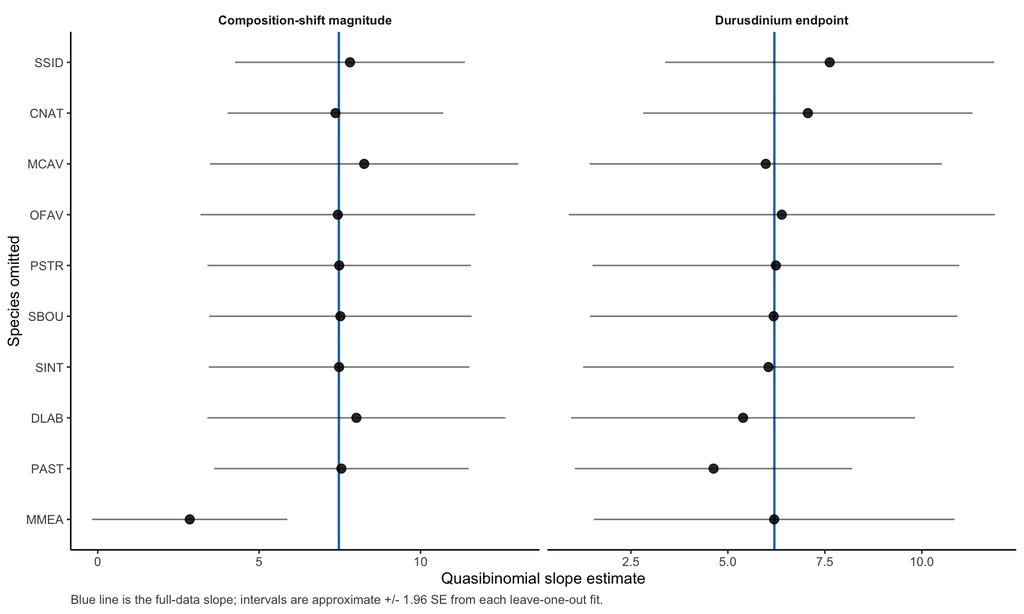

```r
leave_one_out_reference <- integrated_experimental_leave_one_out |>
  filter(omitted_species == "None") |>
  select(endpoint, full_slope = slope)

leave_one_out_plot_data <- integrated_experimental_leave_one_out |>
  filter(omitted_species != "None") |>
  left_join(leave_one_out_reference, by = "endpoint") |>
  mutate(
    slope_lwr = slope - 1.96 * slope_se,
    slope_upr = slope + 1.96 * slope_se,
    omitted_species = fct_reorder(omitted_species, slope)
  )

leave_one_out_plot <- ggplot(
  leave_one_out_plot_data,
  aes(x = omitted_species, y = slope)
) +
  geom_hline(aes(yintercept = full_slope), color = "#1f78b4", linewidth = 0.8) +
  geom_errorbar(aes(ymin = slope_lwr, ymax = slope_upr), width = 0, alpha = 0.55) +
  geom_point(size = 2.7, alpha = 0.85) +
  coord_flip() +
  facet_wrap(~ endpoint, scales = "free_x") +
  labs(
    x = "Species omitted",
    y = "Quasibinomial slope estimate",
    caption = "Blue line is the full-data slope; intervals are approximate +/- 1.96 SE from each leave-one-out fit."
  ) +
  theme_classic() +
  theme(
    strip.background = element_blank(),
    strip.text = element_text(face = "bold"),
    plot.caption = element_text(color = "grey30", hjust = 0)
  )

leave_one_out_plot
```

```r
ggsave(
  "outputs/figures/integrated_experimental_leave_one_species_out.png",
  leave_one_out_plot,
  width = 9,
  height = 5,
  dpi = 300
)
```

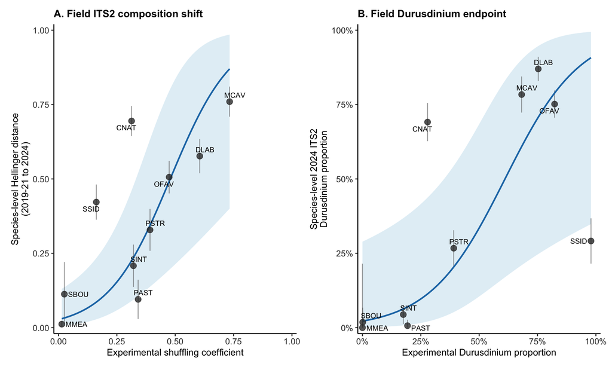

```r
predict_fractional_logit_ci <- function(fit, newdata) {
  prediction <- predict(fit, newdata = newdata, type = "link", se.fit = TRUE)
  critical_value <- qt(0.975, df = fit$df.residual)

  bind_cols(
    newdata,
    tibble(
      fit = plogis(prediction$fit),
      lwr = plogis(prediction$fit - critical_value * prediction$se.fit),
      upr = plogis(prediction$fit + critical_value * prediction$se.fit)
    )
  )
}

weighted_shift_predictions <- predict_fractional_logit_ci(
  fit_shift_fractional_logit_weighted,
  experimental_shift_prediction_grid
)

weighted_clade_d_predictions <- predict_fractional_logit_ci(
  fit_clade_d_fractional_logit_weighted,
  experimental_clade_d_prediction_grid
)

publication_theme <- theme_classic(base_size = 12) +
  theme(
    plot.title = element_text(face = "bold", size = 12),
    axis.title = element_text(size = 11),
    axis.text = element_text(size = 10, color = "grey20"),
    legend.position = "bottom",
    legend.title = element_text(size = 10),
    legend.text = element_text(size = 9),
    plot.margin = margin(6, 8, 6, 8)
  )

fit_color <- "#1f78b4"
point_color <- "grey20"
uncertainty_fill <- "#a6cee3"

species_label_style <- list(
  seed = 2,
  size = 3,
  min.segment.length = 0,
  segment.color = "grey65",
  segment.size = 0.25,
  box.padding = 0.25,
  point.padding = 0.22,
  max.overlaps = Inf
)

experimental_shift_summary_panel <- ggplot(
  experimental_field_shift_plot_data,
  aes(x = mean_shuff_coef, y = Hellinger)
) +
  geom_ribbon(
    data = weighted_shift_predictions,
    aes(x = mean_shuff_coef, ymin = lwr, ymax = upr),
    inherit.aes = FALSE,
    fill = uncertainty_fill,
    alpha = 0.32
  ) +
  geom_errorbar(
    aes(ymin = pmax(0, Hellinger - Hellinger_se), ymax = pmin(1, Hellinger + Hellinger_se)),
    width = 0,
    color = "grey35",
    alpha = 0.55
  ) +
  geom_line(
    data = weighted_shift_predictions,
    aes(y = fit),
    color = fit_color,
    linewidth = 0.9
  ) +
  geom_point(size = 3, color = point_color, alpha = 0.8) +
  do.call(
    ggrepel::geom_text_repel,
    c(list(mapping = aes(label = species_code)), species_label_style)
  ) +
  scale_x_continuous(limits = c(0, 1), expand = expansion(mult = 0.02)) +
  scale_y_continuous(limits = c(0, 1), expand = expansion(mult = 0.02)) +
  labs(
    title = "A. Field ITS2 composition shift",
    x = "Experimental shuffling coefficient",
    y = "Species-level Hellinger distance\n(2019-21 to 2024)"
  ) +
  publication_theme

experimental_clade_d_summary_panel <- ggplot(
  experimental_clade_d_plot,
  aes(x = mean_prop_d, y = its2_prop_d_2024)
) +
  geom_ribbon(
    data = weighted_clade_d_predictions,
    aes(x = mean_prop_d, ymin = lwr, ymax = upr),
    inherit.aes = FALSE,
    fill = uncertainty_fill,
    alpha = 0.32
  ) +
  geom_errorbar(
    aes(ymin = pmax(0, its2_prop_d_2024 - its2_prop_d_2024_se), ymax = pmin(1, its2_prop_d_2024 + its2_prop_d_2024_se)),
    width = 0,
    color = "grey35",
    alpha = 0.55
  ) +
  geom_line(
    data = weighted_clade_d_predictions,
    aes(y = fit),
    color = fit_color,
    linewidth = 0.9
  ) +
  geom_point(size = 3, color = point_color, alpha = 0.8) +
  do.call(
    ggrepel::geom_text_repel,
    c(list(mapping = aes(label = species_code)), species_label_style)
  ) +
  scale_x_continuous(labels = scales::percent_format(), limits = c(0, 1), expand = expansion(mult = 0.02)) +
  scale_y_continuous(labels = scales::percent_format(), limits = c(0, 1), expand = expansion(mult = 0.02)) +
  labs(
    title = "B. Field Durusdinium endpoint",
    x = "Experimental Durusdinium proportion",
    y = "Species-level 2024 ITS2\nDurusdinium proportion"
  ) +
  publication_theme

integrated_experimental_comparison_plot <-
  patchwork::wrap_plots(
    experimental_shift_summary_panel,
    experimental_clade_d_summary_panel,
    widths = c(1, 1),
    guides = "collect"
  ) &
  theme(legend.position = "bottom")

integrated_experimental_comparison_plot
```

```r
ggsave(
  "outputs/figures/integrated_experimental_field_comparison.png",
  integrated_experimental_comparison_plot,
  width = 12,
  height = 5.5,
  dpi = 300
)

ggsave(
  "outputs/figures/integrated_experimental_field_comparison_quasibinomial.png",
  integrated_experimental_comparison_plot,
  width = 12,
  height = 5.5,
  dpi = 300
)
```

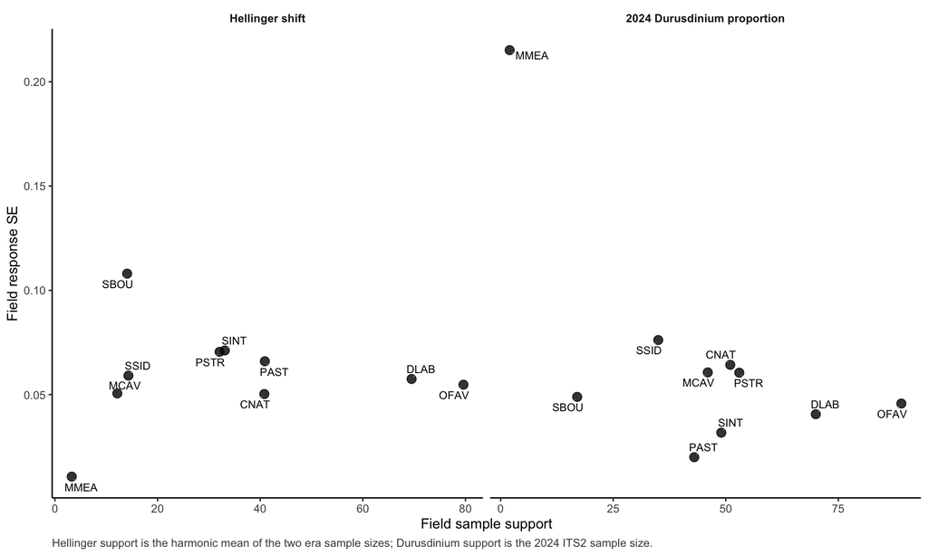

```r
field_response_se_diagnostic <- bind_rows(
  experimental_field_shift_plot_data |>
    transmute(
      endpoint = "Hellinger shift",
      species_code,
      field_sample_support = harmonic_field_n,
      response_se = Hellinger_se
    ),
  experimental_clade_d_plot |>
    transmute(
      endpoint = "2024 Durusdinium proportion",
      species_code,
      field_sample_support = field_n,
      response_se = its2_prop_d_2024_se
    )
) |>
  mutate(endpoint = factor(endpoint, levels = c("Hellinger shift", "2024 Durusdinium proportion")))

field_response_se_diagnostic_plot <- ggplot(
  field_response_se_diagnostic,
  aes(x = field_sample_support, y = response_se)
) +
  geom_point(size = 3, alpha = 0.8) +
  ggrepel::geom_text_repel(
    aes(label = species_code),
    seed = 2,
    size = 3,
    min.segment.length = 0,
    segment.color = "grey65",
    segment.size = 0.25,
    box.padding = 0.25,
    point.padding = 0.22,
    max.overlaps = Inf
  ) +
  facet_wrap(~ endpoint, scales = "free_x") +
  labs(
    x = "Field sample support",
    y = "Field response SE",
    caption = "Hellinger support is the harmonic mean of the two era sample sizes; Durusdinium support is the 2024 ITS2 sample size."
  ) +
  theme_classic() +
  theme(
    strip.background = element_blank(),
    strip.text = element_text(face = "bold"),
    plot.caption = element_text(color = "grey30", hjust = 0)
  )

field_response_se_diagnostic_plot
```

```r
ggsave(
  "outputs/figures/field_response_se_vs_sample_support.png",
  field_response_se_diagnostic_plot,
  width = 9,
  height = 4.5,
  dpi = 300
)
```

# Across-region synthesis

This section combines Upper Keys and Dry Tortugas into one species-level view. The inputs are the region-level compositions above: Upper Keys is standardized by site and depth where possible, and Dry Tortugas is standardized by site but not by depth because depth data are incomplete.

Regions are weighted equally when both regions are available for a species and era. This is intended as an across-region biological synthesis rather than a sample-size-weighted summary dominated by the region with more samples.

```r
across_region_composition |>
  arrange(host_species_code, era) |>
  knitr::kable()
```

| host_species_code | era | n_total | n_regions | regions_included | region_weighting | standardization_context | A | B | C | D | G |
| --- | --- | --- | --- | --- | --- | --- | --- | --- | --- | --- | --- |
| CNAT | 2001-03 | 9 | 1 | Upper Keys | equal | Depth- and site-standardized | 0.0013458 | 0.8510734 | 0.0003275 | 0.1472533 | 0.0000000 |
| CNAT | 2019-21 | 34 | 2 | Dry Tortugas; Upper Keys | equal | Depth- and site-standardized; Site-standardized | 0.0944309 | 0.8950825 | 0.0094106 | 0.0010577 | 0.0000184 |
| CNAT | 2024 | 51 | 2 | Dry Tortugas; Upper Keys | equal | Depth- and site-standardized; Site-standardized | 0.1478717 | 0.1443561 | 0.0165632 | 0.6912090 | 0.0000000 |
| DLAB | 2001-03 | 27 | 1 | Upper Keys | equal | Depth- and site-standardized | 0.0685810 | 0.7864518 | 0.0351519 | 0.1002540 | 0.0095614 |
| DLAB | 2019-21 | 69 | 2 | Dry Tortugas; Upper Keys | equal | Depth- and site-standardized; Site-standardized | 0.0000490 | 0.7587205 | 0.0032962 | 0.2333406 | 0.0045937 |
| DLAB | 2024 | 70 | 2 | Dry Tortugas; Upper Keys | equal | Depth- and site-standardized; Site-standardized | 0.0539761 | 0.0565760 | 0.0195907 | 0.8698572 | 0.0000000 |
| DSTO | 2001-03 | 7 | 1 | Upper Keys | equal | Depth- and site-standardized | 0.0035432 | 0.9948184 | 0.0008247 | 0.0008136 | 0.0000000 |
| DSTO | 2019-21 | 7 | 1 | Upper Keys | equal | Depth- and site-standardized | 0.0001187 | 0.9998813 | 0.0000000 | 0.0000000 | 0.0000000 |
| MCAV | 2019-21 | 7 | 1 | Upper Keys | equal | Depth- and site-standardized | 0.0001801 | 0.0005174 | 0.9977700 | 0.0015325 | 0.0000000 |
| MCAV | 2024 | 46 | 1 | Upper Keys | equal | Depth- and site-standardized | 0.0506806 | 0.0194985 | 0.1460435 | 0.7837774 | 0.0000000 |
| MMEA | 2019-21 | 9 | 1 | Dry Tortugas | equal | Site-standardized | 0.0002202 | 0.9997168 | 0.0000629 | 0.0000000 | 0.0000000 |
| MMEA | 2024 | 2 | 1 | Dry Tortugas | equal | Site-standardized | 0.0000000 | 1.0000000 | 0.0000000 | 0.0000000 | 0.0000000 |
| OFAV | 2001-03 | 26 | 1 | Upper Keys | equal | Depth- and site-standardized | 0.0069211 | 0.6278676 | 0.0120413 | 0.3485876 | 0.0045825 |
| OFAV | 2019-21 | 72 | 2 | Dry Tortugas; Upper Keys | equal | Depth- and site-standardized; Site-standardized | 0.0026877 | 0.4785071 | 0.2902525 | 0.2262704 | 0.0022823 |
| OFAV | 2024 | 89 | 2 | Dry Tortugas; Upper Keys | equal | Depth- and site-standardized; Site-standardized | 0.0930587 | 0.1463652 | 0.0089827 | 0.7515935 | 0.0000000 |
| PAST | 2001-03 | 9 | 1 | Upper Keys | equal | Depth- and site-standardized | 0.9439135 | 0.0163735 | 0.0349569 | 0.0042441 | 0.0005120 |
| PAST | 2019-21 | 39 | 1 | Upper Keys | equal | Depth- and site-standardized | 0.9499384 | 0.0234310 | 0.0252564 | 0.0011291 | 0.0002451 |
| PAST | 2024 | 43 | 1 | Upper Keys | equal | Depth- and site-standardized | 0.9503396 | 0.0410192 | 0.0019668 | 0.0066744 | 0.0000000 |
| PCLI | 2001-03 | 2 | 1 | Upper Keys | equal | Depth- and site-standardized | 0.0070508 | 0.9926713 | 0.0002778 | 0.0000000 | 0.0000000 |
| PCLI | 2019-21 | 4 | 1 | Upper Keys | equal | Depth- and site-standardized | 0.0000000 | 1.0000000 | 0.0000000 | 0.0000000 | 0.0000000 |
| PCLI | 2024 | 9 | 1 | Upper Keys | equal | Depth- and site-standardized | 0.2314355 | 0.3002888 | 0.0000000 | 0.4682756 | 0.0000000 |
| PSTR | 2001-03 | 9 | 1 | Upper Keys | equal | Depth- and site-standardized | 0.0038749 | 0.9887397 | 0.0015834 | 0.0000000 | 0.0058020 |
| PSTR | 2019-21 | 23 | 2 | Dry Tortugas; Upper Keys | equal | Depth- and site-standardized; Site-standardized | 0.0007392 | 0.7765716 | 0.0812195 | 0.1076041 | 0.0338656 |
| PSTR | 2024 | 53 | 2 | Dry Tortugas; Upper Keys | equal | Depth- and site-standardized; Site-standardized | 0.1399056 | 0.5540134 | 0.0389293 | 0.2671517 | 0.0000000 |
| SBOU | 2001-03 | 12 | 1 | Upper Keys | equal | Depth- and site-standardized | 0.1633880 | 0.7495364 | 0.0850998 | 0.0018931 | 0.0000827 |
| SBOU | 2019-21 | 12 | 1 | Upper Keys | equal | Depth- and site-standardized | 0.0659979 | 0.9275019 | 0.0007513 | 0.0000000 | 0.0057489 |
| SBOU | 2024 | 17 | 1 | Upper Keys | equal | Depth- and site-standardized | 0.0795677 | 0.8996787 | 0.0024212 | 0.0183324 | 0.0000000 |
| SINT | 2001-03 | 25 | 1 | Upper Keys | equal | Depth- and site-standardized | 0.2991391 | 0.4989895 | 0.1992622 | 0.0022493 | 0.0003599 |
| SINT | 2019-21 | 25 | 1 | Upper Keys | equal | Depth- and site-standardized | 0.3951025 | 0.5419064 | 0.0605448 | 0.0019031 | 0.0005433 |
| SINT | 2024 | 49 | 1 | Upper Keys | equal | Depth- and site-standardized | 0.4489770 | 0.5068442 | 0.0000828 | 0.0440960 | 0.0000000 |
| SRAD | 2001-03 | 10 | 1 | Upper Keys | equal | Depth- and site-standardized | 0.0955839 | 0.8741493 | 0.0065676 | 0.0236992 | 0.0000000 |
| SRAD | 2019-21 | 4 | 1 | Upper Keys | equal | Depth- and site-standardized | 0.4803068 | 0.2511373 | 0.0188591 | 0.2496968 | 0.0000000 |
| SRAD | 2024 | 10 | 1 | Upper Keys | equal | Depth- and site-standardized | 0.2177006 | 0.7244711 | 0.0014144 | 0.0564139 | 0.0000000 |
| SSID | 2019-21 | 9 | 1 | Upper Keys | equal | Depth- and site-standardized | 0.0358984 | 0.9640318 | 0.0000375 | 0.0000323 | 0.0000000 |
| SSID | 2024 | 35 | 1 | Upper Keys | equal | Depth- and site-standardized | 0.0770868 | 0.6073027 | 0.0241850 | 0.2914255 | 0.0000000 |

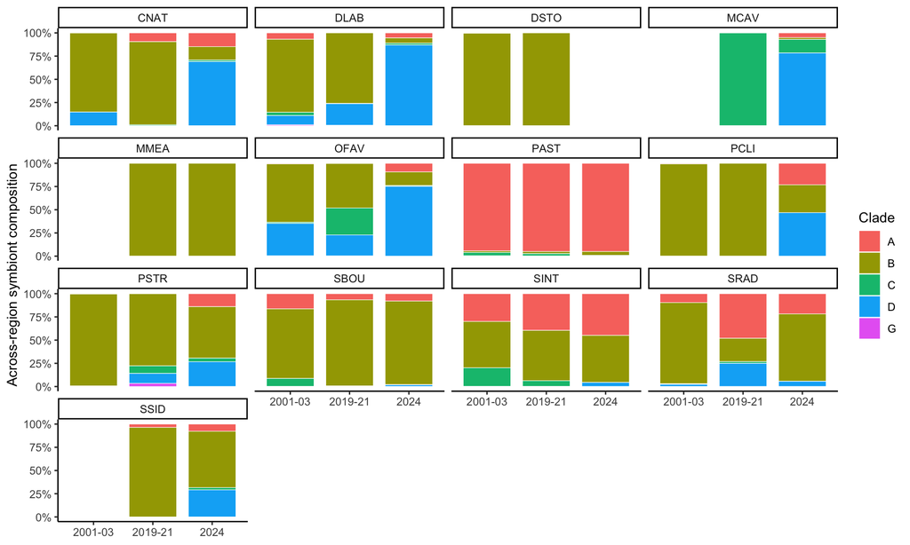

```r
across_region_composition_long <- across_region_composition |>
  pivot_longer(all_of(clades), names_to = "clade", values_to = "proportion") |>
  filter(!is.na(proportion))

across_region_composition_plot <- ggplot(
  across_region_composition_long,
  aes(x = era, y = proportion, fill = clade)
) +
  geom_col(width = 0.8, color = "white", linewidth = 0.2) +
  facet_wrap(~ host_species_code) +
  scale_y_continuous(labels = scales::percent_format(accuracy = 1)) +
  labs(
    x = NULL,
    y = "Across-region symbiont composition",
    fill = "Clade"
  ) +
  theme_classic()

across_region_composition_plot
```

```r
ggsave(
  "outputs/figures/across_region_species_composition.png",
  across_region_composition_plot,
  width = 11,
  height = 7,
  dpi = 300
)
```